# Assignment 2 - DS4Biz Y63

## TextScraping_Classification

### Team Detail

**Team Name**: INu

### *Student 1*

**Student ID**: 61070285  
**Student Full Name**: นายชยพล วนานิยกุล

### *Student 2*

**Student ID**: 61070327  
**Student Full Name**: นายอนุ ม่วงคำ

# Import

```python
import requests
import bs4
from pprint import pprint
import pandas as pd
import numpy as np
import nltk
import seaborn as sns
import matplotlib.pyplot as plt
from nltk.stem.porter import PorterStemmer
from nltk.stem import WordNetLemmatizer
from sklearn.model_selection import train_test_split
from sklearn.metrics import multilabel_confusion_matrix
from sklearn.metrics import accuracy_score, precision_score,recall_score,confusion_matrix, roc_curve, roc_auc_score, hamming_loss,classification_report as cr, precision_recall_curve, average_precision_score
import warnings
warnings.filterwarnings('ignore')
```

# Scraping Data

```python
scrape = []# create blank list
pages =1 #set page count
while True:
    r = requests.get("http://quotes.toscrape.com/page/%i/" % pages)
    soup = bs4.BeautifulSoup(r.content)
    quotes = soup.find_all('div', class_='quote')
    """ตั้งตัวหยุดหน้าหาก เราหาเจอหน้าว่าง"""
    if quotes == []:
        break
    else:
        for find_quote in quotes:
            web_scraping = {} #create dict
            web_scraping["Quote"] = find_quote.find('span', class_='text').text  #finding quote and adding to list
            web_scraping['Author'] = find_quote.find('small', class_='author').text
            web_scraping['Tags'] = [tag.text for tag in find_quote.find_all("a",{"class":"tag"})]
            #(looking for anchor(llink)->{class.tag})
            #ถ้าหากเราไม่ใช้ dict comprehension จะต้องสร้างลูป แล้วหา list มาเก็บค่าtagแล้ว เอาเข้า dictweb_scrapingก่อนscrape.append(web_scrap)
            """
            w/o dict comprehension use list to append data before put it in dict
            tagg = [] #สร้างตัวแปรมาเก็บข้อมูล อยู่นอกรูป ทุกครั้งที่เปลี่ยนหน้าจะเริ่มเก็บข้อมูลใหม่เพื่อไม่ให้มีข้อมูลซ้ำ
            for tag in find_quote.find_all("a",{"class":"tag"}):
                tagg.append(tag.text)
            web_scraping["Tags"] = tagg

            """
            scrape.append(web_scraping)
        pages += 1
```

ในการที่จะดึงข้อมูลมาโดยจะสร้าง list มาเก็บค่าที่ดึงมาโดยจะตั้งตัวแปรquotes จากการหาข้อมูล class quote ถ้า เราจะquoteว่างจะหยุดลูป โดยจะทำการดึงข้อมูลโดยการเก็บข้อมูลใน dict โดยหา class ของแต่ละข้อมูล แต่ Tags ต้องดูเป็น dict ข้อมูลจากใน tag

# Parse the collected data, and store it in an appropriate file format

```python
df =pd.DataFrame(scrape) #สร้าง DataFrame จาก listที่เป็น dict
```

```python
# np.savetxt('target/tags.txt',df['Tags'].values,fmt='%s') #เก็บข้อมูลด้วย numpy
# np.savetxt('datastore/quote.txt', df['Quote'].values, fmt='%s',encoding='utf-8') #เก็บข้อมูลโดย encode = utf8
```

```python
fin = open("target/tags.txt","r",encoding="utf-8")
doc2 = fin.readlines()
fin.close()
doc2[0]#ในทุกข้อมูลจะติด \n มา
```

```
"['change', 'deep-thoughts', 'thinking', 'world']\n"
```

## Load Data and Process

### Load data by use rstrip() to delete '/n'

```python
quote_data = [line.rstrip() for line in open("datastore/quote.txt","r",encoding="utf-8")]
```

ใช้ rstrip()ในการนำ \n ออกมา จากการดึงข้อมูล

### Tokenize Text

```python
from sklearn.feature_extraction.text import CountVectorizer
tokenize = CountVectorizer().build_tokenizer()
tokens1 = tokenize(quote_data[0].lower())
print(tokens1)
```

```
['the', 'world', 'as', 'we', 'have', 'created', 'it', 'is', 'process', 'of', 'our', 'thinking', 'it', 'cannot', 'be', 'changed', 'without', 'changing', 'our', 'thinking']
```

```python
tokenize = CountVectorizer().build_tokenizer()
tokens = []
for token in quote_data:
    tokens.append(tokenize(token.lower()))
    #สร้างลิสต์มาเก็บ token
```

ข้อมูล token จะเป็น listในlist

```python
test = [] #สร้างตัวแปรเก็บลิสต์
for i in tokens:
    """
    สร้างลูปในการเก็บข้อมูลเพื่อให้เป็นข้อมูล list เดียวกัน
    """
    if i == 0:
        test = i
    else:
        for j in i:
            test.append(j)
```

```python
tokens1 = tokenize(str(test))
tokens1[0:5]
```

```
['the', 'world', 'as', 'we', 'have']
```

### Load tag data using .rstrip()

```python
tag_data = [line.rstrip() for line in open('target/tags.txt',"r",encoding="utf-8")]
tag_data[0:5]
```

```
["['change', 'deep-thoughts', 'thinking', 'world']",
 "['abilities', 'choices']",
 "['inspirational', 'life', 'live', 'miracle', 'miracles']",
 "['aliteracy', 'books', 'classic', 'humor']",
 "['be-yourself', 'inspirational']"]
```

ใน tag_data ข้อมูล จะเป็น list แล้วมี string รูปแบบ list อยู่ดังนั้น เราจะดูเข้ามาใน string ข้อมูลแล้วใช้ split ข้อมูลออกมาจะได้ข้อมูลเป็นลิสต์ในรูปแบบ [["'x'","'y'"],[...]]

```python
convert = [i[1 : -1].split(', ') for i in tag_data]  # Change list of String that represent in list format to list of list
```

```python
find_count_tag = []
for _list_ in convert:
    """หา tag ทั้งหมด"""
    for elements in (_list_):
        if _list_ == '': #"ถ้าในลิสต์นั้นเป็น str เปล่าจะ ไม่ใช้"
            continue
        else:
            find_count_tag.append(elements)
```

```python
print(find_count_tag)
```

```
["'change'", "'deep-thoughts'", "'thinking'", "'world'", "'abilities'", "'choices'", "'inspirational'", "'life'", "'live'", "'miracle'", "'miracles'", "'aliteracy'", "'books'", "'classic'", "'humor'", "'be-yourself'", "'inspirational'", "'adulthood'", "'success'", "'value'", "'life'", "'love'", "'ed…
```

```python
count_tag = pd.Series(find_count_tag)
count_tag.value_counts(sort=True)# sort tag
```

```
'love'               14
'life'               13
'inspirational'      13
'humor'              12
'books'              11
                     ..
'sisters'             1
'fairytales'          1
'connection'          1
'live-death-love'     1
'attributed'          1
Length: 138, dtype: int64
```

```python
count_tag.value_counts(sort=True).nlargest(16)#หา15ตัวแปรที่เยอะที่สุด ใช้16พอมีข้อมูลว่าง
```

```
'love'                    14
'life'                    13
'inspirational'           13
'humor'                   12
'books'                   11
'reading'                  7
'friendship'               5
'friends'                  4
'truth'                    4
'attributed-no-source'     3
'simile'                   3
'writing'                  3
'death'                    3
                           3
'children'                 2
'courage'                  2
dtype: int64
```

```python
top_tag = ['love','inspirational','life','humor','books','reading','friendship','friends','truth','writing','death',\
           'attributed-no-source','simile','library','yourself'] #Create top 15 tag
```

```python
label = [] #create list to add label
for tag in convert:
    """
    ข้อมูลใน convert จะอยู่ในรูปแบบที่แปลก ดังนั้นเราจะทำการลบ quote ที่เกินออกมาด้วย replaceเปลี่ยนเป็นช่องว่าง
    """
    new_tag = []
    for tagintoptag in tag:
        if tagintoptag.replace("'","") in top_tag: #replace ' ออกเนื่องจากข้อมูลเป็นรูปแบบ '"deep thoughts"'
            new_tag.append(tagintoptag)
    label.append(new_tag)
```

# Text PreProcessing

ตั้งสมมติฐานในการทำงานโดยจะกำหนด

1.More_Words คือ การตัดคำที่เหลือจำนวนคำเยอะ (min_df = 3)

2.Less_Words คือ การตัดคำทีั่เหลือจำนวนคำที่น้อยซึ่งจะใช้ในการต่อหลังจากการที่นำข้อมูลผู้แต่ง quote มาใช้ (min_df = 5)

โดยกระบวนการตัดคำจะแบ่งเป็นรูปแบบดังนี้

```
1. lemma_tokenizer
```

ซึ่งวิธีอื่นๆ เช่น lemma with pos tag & stem คือจำนวนคำ ที่ได้มีการจัดทำต่างกัน

ซึ่งที่เลือกใช้ lemma เพราะอยากได้ base ของคำ(Morphological) ที่เหมาะสมมากกว่า

```python
def lemma_tokenizer(text):
    standard_tokenizer = CountVectorizer().build_tokenizer()
    tokens = standard_tokenizer(text)
    lemmatizer = nltk.stem.WordNetLemmatizer()
    lemma_tokens = []
    for token in tokens:
        lemma_tokens.append( lemmatizer.lemmatize(token))
    return lemma_tokens
```

```python
vectorizer = CountVectorizer(stop_words="english",min_df = 3,tokenizer=lemma_tokenizer)
X = vectorizer.fit_transform(quote_data)
print(X.shape)
```

```
(100, 60)
```

# Model

ในการทำโมเดล ในช่วงแรกจะมีการเปรียบเทียบโดยใช้ hold out aka.Train test split และได้ TUNE โดย GridSearchCV ก่อนนำไปใช้ใน NestedCV

```python
from sklearn.model_selection import GridSearchCV
from sklearn.model_selection import KFold
from sklearn.model_selection import cross_val_score
from sklearn.model_selection import cross_val_score
```

```python
from sklearn import preprocessing
multi_label = preprocessing.MultiLabelBinarizer()
multi_label.fit(label)
labels = multi_label.transform(label)
labels
```

```
array([[0, 0, 0, ..., 0, 0, 0],
       [0, 0, 0, ..., 0, 0, 0],
       [0, 0, 0, ..., 0, 0, 0],
       ...,
       [0, 0, 0, ..., 1, 0, 0],
       [0, 0, 0, ..., 0, 0, 0],
       [0, 1, 0, ..., 0, 0, 0]])
```

```python
list(multi_label.classes_) #สร้างlistจากclassของlabel
y = pd.DataFrame(labels,columns=list(multi_label.classes_)) #set columns by list that contain name of the columns(tags)
```

```python
#!pip install scikit-multilearn
```

## NaiveBaynes Comparison

```python
from skmultilearn.problem_transform import BinaryRelevance
from skmultilearn.problem_transform import ClassifierChain
from skmultilearn.problem_transform import LabelPowerset
from sklearn.naive_bayes import BernoulliNB, MultinomialNB
```

```python
X_train,X_test,y_train,y_test = train_test_split(X,y,test_size=0.3,random_state=420)
```

### Naive Baynes with BinaryRelevance

```python
bnr_rlv_multi = BinaryRelevance(MultinomialNB())
bnr_rlv_bi = BinaryRelevance(BernoulliNB(alpha=0.7))
bnr_rlv_multi.fit(X_train,y_train)
multi_pred = bnr_rlv_multi.predict(X_test)
bnr_rlv_bi.fit(X_train,y_train)
bi_pred = bnr_rlv_bi.predict(X_test)
"""
    กำหนด labels ในตัว precision&recall เป็น 0,1 ตาม binary ของคำตอบที่เราแบ่งmulti label ให้มี 0,1
"""
print("|-------------------- Accuracy Testing --------------------|")
print(" Multinomia Naive Baynes accuracy: ",accuracy_score(y_test, multi_pred))
print(" Precision Score Multinomial: ",precision_score(y_test,multi_pred,labels=[0,1],average='micro'))
print(" Recall Score Multinomial: ",recall_score(y_test, multi_pred,labels=[0,1],average='micro'))
print("|----------------------------------------------------------|")
print(" Bernoulib Naive Baynes accuracy: ",accuracy_score(y_test, bi_pred))
print(" Precision Score Bernoulib: ",precision_score(y_test,bi_pred,labels=[0,1],average='micro'))
print(" Recall Score Bernoulib: ",recall_score(y_test,bi_pred,labels=[0,1],average='micro'))
```

```
|-------------------- Accuracy Testing --------------------|
 Multinomia Naive Baynes accuracy:  0.36666666666666664
 Precision Score Multinomial:  0.8
 Recall Score Multinomial:  0.8
|----------------------------------------------------------|
 Bernoulib Naive Baynes accuracy:  0.36666666666666664
 Precision Score Bernoulib:  0.75
 Recall Score Bernoulib:  0.6
```

เราจะเห็นว่า Multinomial สามารถทายผล class และ ความถูกต้องโดยรวมของข้อมูลได้ แม่นยำกว่า แม้ accuracy ของโมเดลจะเท่ากันก็ตาม

### Testing with Leave one out

```python
scores1 = cross_val_score(BinaryRelevance(MultinomialNB()) , X , y , cv = X.shape[0]) #CV with all X
scores2 = cross_val_score(BinaryRelevance(BernoulliNB(alpha=0.7)) , X , y , cv = X.shape[0])
```

```python
print("Multinomial Accuracy: %0.2f (+/- %0.2f)" % (scores1.mean()*100, scores1.std())) #
print("Bernoulib Accuracy: %0.2f (+/- %0.2f)" % (scores2.mean()*100, scores2.std()))
```

```
Multinomial Accuracy: 35.00 (+/- 0.48)
Bernoulib Accuracy: 33.00 (+/- 0.47)
```

### Naive Bayne with ClassifierChain

```python
chain_multi = ClassifierChain(MultinomialNB())
chain_bi = ClassifierChain(BernoulliNB(alpha=0.7))
chain_multi.fit(X_train,y_train)
chain_multi_pred = chain_multi.predict(X_test)
chain_bi.fit(X_train,y_train)
chain_bi_pred = chain_bi.predict(X_test)
print("|-------------------- Accuracy Testing --------------------|")
print(" Multinomia Naive Baynes accuracy: ",accuracy_score(y_test, chain_multi_pred))
print(" Precision Score Multinomail: ",precision_score(y_test, chain_multi_pred,labels=[0,1],average='micro'))
print(" Recall Score Multinomial: ",recall_score(y_test, chain_multi_pred,labels=[0,1],average='micro'))
print("|----------------------------------------------------------|")
print(" Bernoulib Naive Baynes accuracy: ",accuracy_score(y_test, chain_bi_pred))
print(" Precision Score Bernoulib: ",precision_score(y_test, chain_bi_pred,labels=[0,1],average='micro'))
print(" Recall Score Bernoulib: ",recall_score(y_test,chain_bi_pred,labels=[0,1],average='micro'))
```

```
|-------------------- Accuracy Testing --------------------|
 Multinomia Naive Baynes accuracy:  0.3333333333333333
 Precision Score Multinomail:  0.8
 Recall Score Multinomial:  0.8
|----------------------------------------------------------|
 Bernoulib Naive Baynes accuracy:  0.36666666666666664
 Precision Score Bernoulib:  0.6
 Recall Score Bernoulib:  0.6
```

จาก ClassifierChain เราะเห็นได้ว่าแม้ความแม่นยำจะต่างไปไม่มาก แต่ค่า Recall&Precision จะต่างกันอยู่ถึง 20%

### Testing with Leave one out

```python
scores1 = cross_val_score(ClassifierChain(MultinomialNB()) , X , y , cv = X.shape[0])
scores2 = cross_val_score(ClassifierChain(BernoulliNB(alpha=0.7)) , X , y , cv = X.shape[0])
print("Multinomial Accuracy: %0.2f (+/- %0.2f)" % (scores1.mean()*100, scores1.std()))
print("Bernoulib Accuracy: %0.2f (+/- %0.2f)" % (scores2.mean()*100, scores2.std()))
```

```
Multinomial Accuracy: 33.00 (+/- 0.47)
Bernoulib Accuracy: 33.00 (+/- 0.47)
```

### Naive Baynes with LabelPowerset

```python
multi_power = LabelPowerset(MultinomialNB())
bi_power = LabelPowerset(BernoulliNB(alpha=0.7))
multi_power.fit(X_test,y_test)
multi_power_pred = multi_power.predict(X_test)
bi_power.fit(X_test,y_test)
bi_power_pred = bi_power.predict(X_test)
print("|-------------------- Accuracy Testing --------------------|")
print(" Multinomia Naive Baynes accuracy: ",accuracy_score(y_test, multi_power_pred))
print(" Precision Score : ",precision_score(y_test, multi_power_pred,labels=[0,1],average='micro'))
print(" Recall Score : ",recall_score(y_test, multi_power_pred,labels=[0,1],average='micro'))
print("|----------------------------------------------------------|")
print(" Bernoulib Naive Baynes accuracy: ",accuracy_score(y_test, bi_power_pred))
print(" Precision Score : ",precision_score(y_test, bi_power_pred,average='micro'))
print(" Recall Score : ",recall_score(y_test, bi_power_pred,average='micro'))
```

```
|-------------------- Accuracy Testing --------------------|
 Multinomia Naive Baynes accuracy:  0.6666666666666666
 Precision Score :  1.0
 Recall Score :  0.6
|----------------------------------------------------------|
 Bernoulib Naive Baynes accuracy:  0.43333333333333335
 Precision Score :  1.0
 Recall Score :  0.12903225806451613
```

### Testing with Leave one out

```python
scores1 = cross_val_score(multi_power , X , y , cv = X.shape[0])
scores2 = cross_val_score( bi_power, X , y , cv = X.shape[0])
print("Multinomial Accuracy: %0.2f (+/- %0.2f)" % (scores1.mean()*100, scores1.std()))
print("Bernoulib Accuracy: %0.2f (+/- %0.2f)" % (scores2.mean()*100, scores2.std()))
```

```
Multinomial Accuracy: 33.00 (+/- 0.47)
Bernoulib Accuracy: 33.00 (+/- 0.47)
```

Label Powerset traines on all unique label combinations found in the training data. ดังนั้น การทำการคำนวณหรือ test ที่มีการซับซ้อนหรือเยอะเช่นการเปรียบเทียบที่เยอะเกินไปอาจทำให้ความแม่นยำลดลง

### Nested CV

```python
from numpy import mean
from numpy import std
```

```python
models_lst = [BinaryRelevance(),BinaryRelevance(),ClassifierChain(),ClassifierChain(),LabelPowerset(),LabelPowerset()]#Model list
"""สำหรับการทำ Multi label tech เราจะต้องกำหนดโมเดลเป็นการทำmulti แล้วสร้างพารามีเตอร์ที่มี Classifierออกมา
        ซึ่งพอเรากำหนด classifier ตัว parameter จะต้องใส่ classifer__นำหน้าเสมอ
    """
parameter = [{ #Create Parameter for tune

        'classifier': [MultinomialNB()],
        'classifier__alpha': [0.5,0.7, 1.0,10.0]
    },
    {
        'classifier':[BernoulliNB()],
        'classifier_alpha': [0.5,0.7,1.0,10.0]
    }
]

model_name = ['BinaryRelevanceMultinomial','BinaryRelevanceBernoulli','ClassifierChainMultinomial'\
             ,'ClassifierChainBernoulli','LabelPowersetMultinobial','LabelPowersetBernoulli']
```

```python
count = 0
for i in models_lst:
    # Choose cross-validation techniques for the inner and outer loops,
    # independently of the dataset.
    inner_cv = KFold(n_splits=4, shuffle=True, random_state=2) #Create K-Fold for shuffle parameter / cv สำหรับการเช็คข้างใน
    outer_cv = KFold(n_splits=4, shuffle=True, random_state=2) #ใช้ภายนอก
    # Optimizing Parameter
    clf = GridSearchCV(i, parameter[0:1], cv=inner_cv) # หาค่าพารามีเตอร์ที่ดีที่สุด
    clf.fit(X, y)

    # Nested CV with parameter optimization
    nested_score = cross_val_score(clf, X, y, cv=outer_cv)
    print(model_name[count]+":  ")
    print('Nested_CV :  '+'%.2f ' %(nested_score.mean()*100)+' %')
    print('Best_parameter:  '+str(clf.best_params_))
    print('')
    count += 1
```

```
BinaryRelevanceMultinomial:
Nested_CV :  34.00  %
Best_parameter:  {'classifier': MultinomialNB(alpha=10.0), 'classifier__alpha': 10.0}

BinaryRelevanceBernoulli:
Nested_CV :  34.00  %
Best_parameter:  {'classifier': MultinomialNB(alpha=10.0), 'classifier__alpha': 10.0}

ClassifierChainMultinomial:
Nested_CV :  34.00  %
Best_parameter:  {'classifier': MultinomialNB(alpha=10.0), 'classifier__alpha': 10.0}

ClassifierChainBernoulli:
Nested_CV :  34.00  %
Best_parameter:  {'classifier': MultinomialNB(alpha=10.0), 'classifier__alpha': 10.0}

LabelPowersetMultinobial:
Nested_CV :  33.00  %
Best_parameter:  {'classifier': MultinomialNB(alpha=10.0), 'classifier__alpha': 10.0}

LabelPowersetBernoulli:
Nested_CV :  33.00  %
Best_parameter:  {'classifier': MultinomialNB(alpha=10.0), 'classifier__alpha': 10.0}
```

### Naive Baynes Basic Comparison Summary

ในการทดสอบ Naive Baynes เราได้ทำการทดสอบด้วย Naive Baynes สองแบบคือ Multinomial&Bernoulli

โดยใช้หลักการของ Multi learn 3แบบคือ

```
1. BinaryRelevance -Transforms a multi-label classification problem with L labels into L single-label separate binary classification problems. แยก y ออกแล้วดูเป็นตัวๆ

2. ClassifierChain- ค่อยๆรวม class(y1,y2)ไปจนถึง yn

3. LabelPowerset - การดูรวมคลาสแล้วเข้าสู่รูปแบบของความน่าจะเป็นในการหาโอกาสที่จะเกิดขึ้น
```

เราจะเห็นได้ว่าหากเราอิงความแม่นยำและ Precision&Recall เราจะเห็นว่า Multinomial จะดีกว่ารวมถึงการใช้ควบคู่กับ LabelPowerSet

แต่ถ้าเราเปรียบเทียบจากการทำ Leave one out จะเห็นได้ว่า BinaryRelevance ของ Multinomial ให้ค่าผลลัพธ์ดีที่สุดคือ 35% ซึ่งหมายความว่า Train test split ที่แบ่ง อาจเป็น lucky split

ถ้าหากเรา Tune parameter with gridsearch CV แล้วนำมาหา nested cv จะได้ค่าความแม่นยำใกล้เคียงกับ leave one out ที่ไม่ได้ Tune

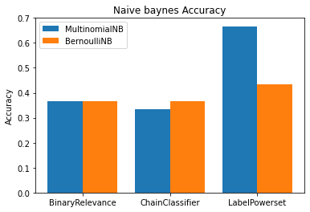

```python
multi_acc = (accuracy_score(y_test, multi_pred),accuracy_score(y_test, chain_multi_pred),accuracy_score(y_test, multi_power_pred))
bi_acc = (accuracy_score(y_test, bi_pred),accuracy_score(y_test, chain_bi_pred),accuracy_score(y_test, bi_power_pred))
width = 0.4
plt.bar(np.arange(3),multi_acc,width,label ="MultinomialNB")
plt.bar(np.arange(3)+width,bi_acc,width,label ="BernoulliNB")# + width เพราะให้กราฟที่plotออกมาไม่ติดกัน
plt.ylabel('Accuracy')
plt.title('Naive baynes Accuracy')

plt.xticks(np.arange(3) + width / 2, ('BinaryRelevance', 'ChainClassifier', 'LabelPowerset'))
plt.legend(loc='best')
plt.show()
```

กราฟแสดงการเปรียบเทียบความแม่นยำในการทำ train test split โดยมีโอกาสเป็น Lucky Split

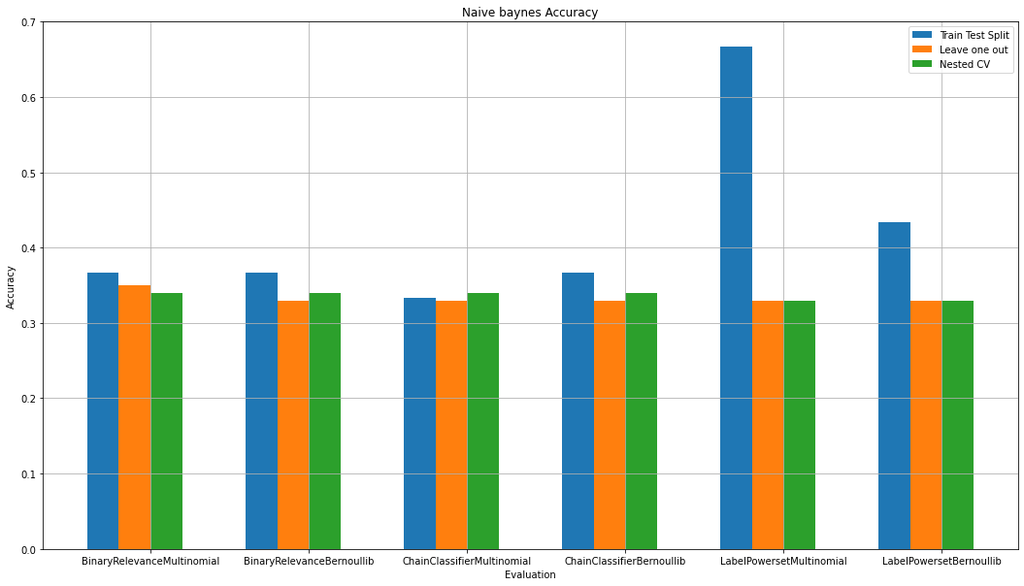

```python
fig, ax = plt.subplots(figsize = (18,10))
tts = (accuracy_score(y_test, multi_pred),accuracy_score(y_test, bi_pred),accuracy_score(y_test, chain_multi_pred),\
       accuracy_score(y_test, chain_bi_pred),accuracy_score(y_test, multi_power_pred),accuracy_score(y_test, bi_power_pred))
loo = (0.35,0.33,0.33,0.33,0.33,0.33)
nested = (0.34,0.34,0.34,0.34,0.33,0.33)
width = 0.2
plt.bar(np.arange(6),tts,width,label ="Train Test Split")
plt.bar(np.arange(6)+(width),loo,width,label ="Leave one out")
plt.bar(np.arange(6)+(2*width),nested,width,label ="Nested CV")
plt.ylabel('Accuracy')
plt.title('Naive baynes Accuracy')
plt.xlabel('Evaluation')
plt.xticks(np.arange(6) + (1.5*width) , ('BinaryRelevanceMultinomial','BinaryRelevanceBernoullib', \
                        'ChainClassifierMultinomial','ChainClassifierBernoullib', 'LabelPowersetMultinomial','LabelPowersetBernoullib'))
plt.legend(loc='best')
plt.grid()
plt.show()
```

จากภาพด้านบนเราจะเห็นได้ว่าในส่วนของการทำ traintestsplit มีค่าความแม่นยำที่สูงเกินกว่าปกติ อาจเป็นเพราะ lucky split ที่ไม่เหมาะสม

ในส่วนของการทำ Cross valid จะสังเกตุ เห็นได้ว่าค่าที่มีนั้นใกล้เคียงกัน

## Tree

```python
Xt_train,Xt_test,yt_train,yt_test = train_test_split(X,y,random_state=420)
```

```python
from sklearn.ensemble import RandomForestClassifier
from sklearn.ensemble import BaggingClassifier
from sklearn.tree import ExtraTreeClassifier
from sklearn.tree import DecisionTreeClassifier
```

### Random Forest

```python
rfc = RandomForestClassifier()
rfc.fit(Xt_train,yt_train)
rfc_pred = rfc.predict(Xt_test)
#In multi-label classification, this is the subset accuracy which is a harsh metric
#require for each sample that each label set be correctly predicted
```

```python
print("Random forest Accuracy: ",rfc.score(Xt_test,yt_test))
```

```
Random forest Accuracy:  0.4
```

```python
from sklearn import metrics

print('Mean Absolute Error:', metrics.mean_absolute_error(yt_test, rfc_pred))
print('Mean Squared Error:', metrics.mean_squared_error(yt_test, rfc_pred))
print('Root Mean Squared Error:', np.sqrt(metrics.mean_squared_error(yt_test, rfc_pred)))
```

```
Mean Absolute Error: 0.061333333333333344
Mean Squared Error: 0.061333333333333344
Root Mean Squared Error: 0.24765567494675617
```

```python
scores1_rt = cross_val_score(rfc , X , y , cv = X.shape[0])
print("Random Forest Accuracy: %0.2f (+/- %0.2f)" % (scores1_rt.mean()*100, scores1_rt.std())) #find mean with std
#Result จะบอกช่วง คะแนน(mean)แล้วดูค่าความแปรปวน + -
```

```
Random Forest Accuracy: 34.00 (+/- 0.47)
```

```python
# random n_estimator โดยการใช้ numpy linspace
n_estimators = [int(x) for x in np.linspace(start = 5, stop = 60, num = 5)]
# Number of features ที่จะถูก split ออกมา
max_features = ['auto', 'sqrt']
# ความลึกสูงสุด (ไม่ควรลึกเกินไปและน้อยเกินไป)
max_depth = [2,4]
# Minimum samples ที่ใช้ในการแตก node
min_samples_split = [2, 5]
# Minimum samples required at each leaf node
min_samples_leaf = [1, 2]
# เลือกตัวอย่างในการ training ของต้นไม้แต่ละต้น
bootstrap = [True, False]
"""
    ใช้ข้อมูลจากด้านบนมาใส่ใน dick ในการจูนค่า parameter
"""
param_grid = {'n_estimators': n_estimators,
               'max_features': max_features,
               'max_depth': max_depth,
               'min_samples_split': min_samples_split,
               'min_samples_leaf': min_samples_leaf,
               'bootstrap': bootstrap}
```

```python
inner_cv = KFold(n_splits=4, shuffle=True, random_state=2)
outer_cv = KFold(n_splits=4, shuffle=True, random_state=2)
# Optimizing Parameter
clf = GridSearchCV(RandomForestClassifier(random_state=42), param_grid, verbose=2, cv=inner_cv,n_jobs=4) #Verbose =2 red box
#n_jobs คือใส้ทำ task ขนาดกันเป็นจำนวน4
clf.fit(X, y)
# Nested CV with parameter optimization
nested_score = cross_val_score(clf, X, y, cv=outer_cv)
print('RandomForest : ')
print('Nested_CV :  '+'%.2f ' %(nested_score.mean()*100)+' %')
print('Best_parameter:  '+str(clf.best_params_))
print('')
```

```
Fitting 4 folds for each of 160 candidates, totalling 640 fits
```

```
[Parallel(n_jobs=4)]: Using backend LokyBackend with 4 concurrent workers.
[Parallel(n_jobs=4)]: Done  34 tasks      | elapsed:    1.9s
[Parallel(n_jobs=4)]: Done 276 tasks      | elapsed:    6.3s
[Parallel(n_jobs=4)]: Done 640 out of 640 | elapsed:   13.0s finished
[Parallel(n_jobs=4)]: Using backend LokyBackend with 4 concurrent workers.
```

```
Fitting 4 folds for each of 160 candidates, totalling 640 fits
```

```
[Parallel(n_jobs=4)]: Done  58 tasks      | elapsed:    1.3s
[Parallel(n_jobs=4)]: Done 300 tasks      | elapsed:    6.6s
[Parallel(n_jobs=4)]: Done 640 out of 640 | elapsed:   12.4s finished
[Parallel(n_jobs=4)]: Using backend LokyBackend with 4 concurrent workers.
```

```
Fitting 4 folds for each of 160 candidates, totalling 640 fits
```

```
[Parallel(n_jobs=4)]: Done  92 tasks      | elapsed:    1.7s
[Parallel(n_jobs=4)]: Done 576 tasks      | elapsed:   10.4s
[Parallel(n_jobs=4)]: Done 640 out of 640 | elapsed:   11.5s finished
[Parallel(n_jobs=4)]: Using backend LokyBackend with 4 concurrent workers.
```

```
Fitting 4 folds for each of 160 candidates, totalling 640 fits
```

```
[Parallel(n_jobs=4)]: Done  92 tasks      | elapsed:    1.5s
[Parallel(n_jobs=4)]: Done 576 tasks      | elapsed:    9.3s
[Parallel(n_jobs=4)]: Done 640 out of 640 | elapsed:   10.3s finished
[Parallel(n_jobs=4)]: Using backend LokyBackend with 4 concurrent workers.
```

```
Fitting 4 folds for each of 160 candidates, totalling 640 fits
```

```
[Parallel(n_jobs=4)]: Done  92 tasks      | elapsed:    1.5s
[Parallel(n_jobs=4)]: Done 576 tasks      | elapsed:    9.2s
```

```
RandomForest :
Nested_CV :  36.00  %
Best_parameter:  {'bootstrap': False, 'max_depth': 4, 'max_features': 'auto', 'min_samples_leaf': 1, 'min_samples_split': 2, 'n_estimators': 5}
```

```
[Parallel(n_jobs=4)]: Done 640 out of 640 | elapsed:   10.2s finished
```

verbosity level ref:http://www2.cs.uregina.ca/~dbd/cs831/notes/ml/dtrees/c4.5/verbrules.html

### Decision Tree

```python
dct = DecisionTreeClassifier()
dct.fit(Xt_train,yt_train)
dct_pred = dct.predict(Xt_test)
```

```python
print("Decision Tree Accuracy: ",dct.score(Xt_test,yt_test))
```

```
Decision Tree Accuracy:  0.24
```

```python
print('Mean Absolute Error:', metrics.mean_absolute_error(yt_test, dct_pred))
print('Mean Squared Error:', metrics.mean_squared_error(yt_test, dct_pred))
print('Root Mean Squared Error:', np.sqrt(metrics.mean_squared_error(yt_test, dct_pred)))
```

```
Mean Absolute Error: 0.08800000000000002
Mean Squared Error: 0.08800000000000002
Root Mean Squared Error: 0.29664793948382656
```

```python
scores1_dt = cross_val_score(rfc , X , y , cv = X.shape[0])
print("Random Forest Accuracy: %0.2f (+/- %0.2f)" % (scores1_dt.mean()*100, scores1_dt.std()))
```

```
Random Forest Accuracy: 35.00 (+/- 0.48)
```

```python
params = {
        'max_leaf_nodes': list(range(2, 100)),  #leaft node เป็นเลขตามช่วงที่กำหนดเอาไว้
        'min_samples_split': [2, 3, 4]
        }
inner_cv = KFold(n_splits=4, shuffle=True, random_state=2)
outer_cv = KFold(n_splits=4, shuffle=True, random_state=2)
# Optimizing Parameter
clf = GridSearchCV(DecisionTreeClassifier(random_state=42), params, verbose=1, cv=inner_cv) #verbose=1คือกล่องสีแดงด้านล่าง
clf.fit(X, y)
# Nested CV with parameter optimization
nested_score = cross_val_score(clf, X, y, cv=outer_cv)
print('DecisionTree : ')
print('Nested_CV :  '+'%.2f ' %(nested_score.mean()*100)+' %')
print('Best_parameter:  '+str(clf.best_params_))
print('')
```

```
Fitting 4 folds for each of 294 candidates, totalling 1176 fits
```

```
[Parallel(n_jobs=1)]: Using backend SequentialBackend with 1 concurrent workers.
[Parallel(n_jobs=1)]: Done 1176 out of 1176 | elapsed:    6.7s finished
[Parallel(n_jobs=1)]: Using backend SequentialBackend with 1 concurrent workers.
```

```
Fitting 4 folds for each of 294 candidates, totalling 1176 fits
```

```
[Parallel(n_jobs=1)]: Done 1176 out of 1176 | elapsed:    6.9s finished
[Parallel(n_jobs=1)]: Using backend SequentialBackend with 1 concurrent workers.
```

```
Fitting 4 folds for each of 294 candidates, totalling 1176 fits
```

```
[Parallel(n_jobs=1)]: Done 1176 out of 1176 | elapsed:    6.5s finished
[Parallel(n_jobs=1)]: Using backend SequentialBackend with 1 concurrent workers.
```

```
Fitting 4 folds for each of 294 candidates, totalling 1176 fits
```

```
[Parallel(n_jobs=1)]: Done 1176 out of 1176 | elapsed:    6.5s finished
[Parallel(n_jobs=1)]: Using backend SequentialBackend with 1 concurrent workers.
```

```
Fitting 4 folds for each of 294 candidates, totalling 1176 fits
DecisionTree :
Nested_CV :  37.00  %
Best_parameter:  {'max_leaf_nodes': 10, 'min_samples_split': 3}
```

```
[Parallel(n_jobs=1)]: Done 1176 out of 1176 | elapsed:    5.8s finished
```

### Tree Summary

ในการใช้ Tree จะได้ค่าแม่นยำเพียง 36%และ37%ตามลำดับ โดยใช้ best parameter ตามที่ตั้งค่าเอาไว้

## Logistic Regression

Test with BinaryRelevance and ClassifierChain

สำหรับ LabelPowerset การนำ LogisticRegression มาใช้ แบบ multi label จะดูไม่เหมาะสมต่อการทำ X ,y1,y2,...,yn

จึงเลือกใช้แค่สองวิธีแล้วนำมาเปรัยบเทียบกัน

```python
from sklearn.linear_model import LogisticRegression
```

```python
lr = LogisticRegression()
bi_lr = BinaryRelevance(lr)
bi_lr.fit(X_train,y_train)
bi_pred = bi_lr.predict(X_test)
cc_lr = ClassifierChain(lr)
cc_lr.fit(X_train,y_train)
predict=cc_lr.predict(X_test)
print("|------------------------- Accuracy Testing -------------------------|")
print("  Logistic Regression with BinaryRelevance: ",accuracy_score(y_test,bi_pred))
print("  Precision Score : ",precision_score(y_test, bi_pred,labels=[0,1],average='micro'))
print("  Recall Score : ",recall_score(y_test, bi_pred,labels=[0,1],average='micro'))
print("|--------------------------------------------------------------------|")
print("  Logistic Regression with Classifier Chain: ",accuracy_score(y_test,predict))
print("  Precision Score : ",precision_score(y_test, predict,labels=[0,1],average='micro'))
print("  Recall Score : ",recall_score(y_test, predict,labels=[0,1],average='micro'))
```

```
|------------------------- Accuracy Testing -------------------------|
  Logistic Regression with BinaryRelevance:  0.43333333333333335
  Precision Score :  1.0
  Recall Score :  0.4
|--------------------------------------------------------------------|
  Logistic Regression with Classifier Chain:  0.43333333333333335
  Precision Score :  1.0
  Recall Score :  0.4
```

```python
lr_pram = { 'classifier': [LogisticRegression()],
            'classifier__penalty':('l1', 'l2'),
              'classifier__solver':('newton-cg', 'lbfgs', 'liblinear', 'sag', 'saga'),
          'classifier__C':[0.01, 0.1, 1, 10]}
```

```python
inner_cv = KFold(n_splits=4, shuffle=True, random_state=2)
outer_cv = KFold(n_splits=4, shuffle=True, random_state=2)
# Optimizing Parameter
clf = GridSearchCV(BinaryRelevance(), lr_pram, cv=inner_cv)
clf.fit(X, y)
# Nested CV with parameter optimization
# nested_score = cross_val_score(clf, X, y, cv=outer_cv)
# print('LogisticRegression : ')
# print('Nested_CV :  '+'%.2f ' %(nested_score.mean()*100)+' %')
# print('Best_parameter:  '+str(clf.best_params_))
# print('')
"""ไม่สามารถรันที่เดียวได้เลยแยกรันโดยจูนพารามีเตอร์ตามด้านล่าง"""
```

```
'ไม่สามารถรันที่เดียวได้เลยแยกรันโดยจูนพารามีเตอร์ตามด้านล่าง'
```

```python
lr = LogisticRegression(solver='liblinear',penalty='l1')
```

```python
nested_score = cross_val_score(BinaryRelevance(lr), X, y, cv=outer_cv)
print('LogisticRegression : ')
print('Nested_CV :  '+'%.2f ' %(nested_score.mean()*100)+' %')
print('Best_parameter:  '+str(clf.best_params_))
print('')
```

```
LogisticRegression :
Nested_CV :  36.00  %
Best_parameter:  {'classifier': LogisticRegression(C=1, penalty='l1', solver='liblinear'), 'classifier__C': 1, 'classifier__penalty': 'l1', 'classifier__solver': 'liblinear'}
```

```python
clf = GridSearchCV(ClassifierChain(), lr_pram, cv=inner_cv)
clf.fit(X, y)
```

```
GridSearchCV(cv=KFold(n_splits=4, random_state=2, shuffle=True),
             estimator=ClassifierChain(require_dense=[True, True]),
             param_grid={'classifier': [LogisticRegression(C=1, penalty='l1',
                                                           solver='liblinear')],
                         'classifier__C': [0.01, 0.1, 1, 10],
                         'classifier__penalty': ('l1', 'l2'),
                         'classifier__solver': ('newton-cg', 'lbfgs',
                                                'liblinear', 'sag', 'saga')})
```

```python
nested_score = cross_val_score(ClassifierChain(lr), X, y, cv=outer_cv)
print('LogisticRegression : ')
print('Nested_CV :  '+'%.2f ' %(nested_score.mean()*100)+' %')
print('Best_parameter:  '+str(clf.best_params_))
print('')
```

```
LogisticRegression :
Nested_CV :  36.00  %
Best_parameter:  {'classifier': LogisticRegression(C=1, penalty='l1', solver='liblinear'), 'classifier__C': 1, 'classifier__penalty': 'l1', 'classifier__solver': 'liblinear'}
```

### Logistic Regression Summary

ในการใช้ Logistic Regression หา label เราได้ best parameter มาคือ C=1, penalty='l1', solver='liblinear' ให้ค่าความแม่นยำ 36% โดยเป็นการหาแบบ BinaryRelevance&ClassifierChain ด้วยการทำ NestCv

## Multilabel kNN

```python
from skmultilearn.adapt import MLkNN
from scipy.sparse import csr_matrix, lil_matrix
```

```python
knn = MLkNN(k=15)
y_trains = y_train
x_train = lil_matrix(X_train).toarray()
y_trains = lil_matrix(y_trains).toarray()
x_test = lil_matrix(X_test).toarray()
knn.fit(x_train, y_trains)
pred = knn.predict(x_test)
print("MultiLabel kNN Accuracy: ",accuracy_score(y_test,pred))
```

```
MultiLabel kNN Accuracy:  0.43333333333333335
```

```python
X_knn = lil_matrix(X).toarray()
y_knn = lil_matrix(y).toarray()
knn_pram = {'k': range(1,15), 's': [0.5, 0.7, 1.0]}
inner_cv = KFold(n_splits=4, shuffle=True, random_state=2)
outer_cv = KFold(n_splits=4, shuffle=True, random_state=2)
# Optimizing Parameter
clf = GridSearchCV(MLkNN(), knn_pram, cv=inner_cv)
clf.fit(X_knn, y_knn)
# Nested CV with parameter optimization
nested_score = cross_val_score(clf, X_knn, y_knn, cv=outer_cv)
print('Multiple kNN : ')
print('Nested_CV :  '+'%.2f ' %(nested_score.mean()*100)+' %')
print('Best_parameter:  '+str(clf.best_params_))
print('')
```

```
Multiple kNN :
Nested_CV :  35.00  %
Best_parameter:  {'k': 7, 's': 0.7}
```

### MLkNN Summary

จากการทำ GridSearchCV ได้ parameter ที่ดีคือใช้ k=7 และ s =0.7 โดยให้ความแม่นยำอยู่ที่ 35%

# ใช้ข้อมูลผู้แต่งต่อหลังข้อมูล

ในการจะใช้ข้อมูลชื่อของผู้แต่งจะอยู่ในรูป FirstName-Surname เพื่อนำไปหาในเว็บแต่ข้อมูลที่มีนั้นอยู่ในรูปแบบ FirstName Surname

ซึ่งพอข้อมูลแบบนี้จะทำให้ มีข้อมูลมากขึ้น เราสามารถเช็คโดยเลือกตัดคำได้ โดยใช้ min_df = 3 และ min_df = 5

```python
author = df['Author']
for _split_ in range(0,100):
    "split firstname and surname"
    author[_split_] = author[_split_].split(" ")
```

```python
for i in range(0,100):
    "join by using -"
    author[i] = ('-').join(author[i]) #join ข้อมูลหลังจาก splitชื่อกับนามสกุลออกให้เป็น Fname-Sname
```

ที่เราต้องsplitและjoinกันใหม่โดยใช้ - เนื่องจากข้อมูลเวลาเราหา Author detail link web จะอยู่ในรูปแบบ Fname-Sname แต่เวลาเราดึงข้อมูลมาจากเป็นเว้นวรรค

```python
test_df = pd.DataFrame(author)
df['Author'] = test_df
detail = []
for i in df['Author']:
    r = requests.get("https://quotes.toscrape.com/author/%s/" %i)
    soup = bs4.BeautifulSoup(r.content)
    quotes = soup.find_all('div', class_='author-details')
    for find_detail in quotes:
        auothor_datail = {}
        auothor_datail["Details"] = find_detail.find(class_='author-description').text
        detail.append(auothor_datail)
detail[0:2] #ข้อมูลจะติด \n มา
```

```
[{'Details': '\n        In 1879, Albert Einstein was born in Ulm, Germany. He completed his Ph.D. at the University of Zurich by 1909. His 1905 paper explaining the photoelectric effect, the basis of electronics, earned him the Nobel Prize in 1921. His first paper on Special Relativity Theory, also …
 {'Details': '\n'}]
```

```python
details = pd.DataFrame(detail)
for i in details['Details']:
    "ใช้ loop ทำการ strip ข้อมูลที่เป็น\nอย่างเดียวในแต่ละrow"
    details['Details'].replace(i,i.rstrip(),inplace=True)
df['Details'] = details
```

```python
df['Quote']+df['Details']
```

```
0     “The world as we have created it is a process ...
1     “It is our choices, Harry, that show what we t...
2     “There are only two ways to live your life. On...
3     “The person, be it gentleman or lady, who has ...
4     “Imperfection is beauty, madness is genius and...
                            ...
95    “You never really understand a person until yo...
96    “You have to write the book that wants to be w...
97    “Never tell the truth to people who are not wo...
98          “A person's a person, no matter how small.”
99    “... a mind needs books as a sword needs a whe...
Length: 100, dtype: object
```

## Save Quote+Author Details data

```python
#np.savetxt('datastore/AllQuoteAndDetails.txt', (df['Quote']+df['Details']).values, fmt='%s',encoding='utf-8')
```

## Load Quote and AuthorDetail Data

```python
mix_data = [line.rstrip() for line in open('datastore/AllQuoteAndDetails.txt',"r",encoding="utf-8")]
#use data from text files with strip\n
```

```python
def lemma_tokenizer(text):
    standard_tokenizer = CountVectorizer().build_tokenizer()
    tokens = standard_tokenizer(text)
    lemmatizer = nltk.stem.WordNetLemmatizer()
    lemma_tokens = []
    for token in tokens:
        lemma_tokens.append( lemmatizer.lemmatize(token))
    return lemma_tokens
```

## Weight

สรุปของ Weight จะไม่ค่อยเยอะมากแต่เนื้อหาการเปรียบเทียบจะไปอยู่ในสรุปตอนจบ

### More Word

min_df = 3

```python
vectorizer = CountVectorizer(stop_words="english",min_df = 3, tokenizer= lemma_tokenizer)
X = vectorizer.fit_transform(mix_data)
X.shape
```

```
(100, 1027)
```

## NaiveBaynes Comparison

```python
X_train,X_test,y_train,y_test = train_test_split(X,y,test_size=0.3,random_state=420)
```

### Naive Baynes with BinaryRelevance

```python
bnr_rlv_multi = BinaryRelevance(MultinomialNB())
bnr_rlv_bi = BinaryRelevance(BernoulliNB(alpha=0.7))
bnr_rlv_multi.fit(X_train,y_train)
multi_pred = bnr_rlv_multi.predict(X_test)
bnr_rlv_bi.fit(X_train,y_train)
bi_pred = bnr_rlv_bi.predict(X_test)
"""
    กำหนด labels ในตัว precision&recall เป็น 0ม1 ตาม binary ของคำตอบที่เราแบ่งmulti label ให้มี 0,1
"""
print("|-------------------- Accuracy Testing --------------------|")
print(" Multinomia Naive Baynes accuracy: ",accuracy_score(y_test, multi_pred))
print(" Precision Score Multinomial: ",precision_score(y_test,multi_pred,labels=[0,1],average='micro'))
print(" Recall Score Multinomial: ",recall_score(y_test, multi_pred,labels=[0,1],average='micro'))
print("|----------------------------------------------------------|")
print(" Bernoulib Naive Baynes accuracy: ",accuracy_score(y_test, bi_pred))
print(" Precision Score Bernoulib: ",precision_score(y_test,bi_pred,labels=[0,1],average='micro'))
print(" Recall Score Bernoulib: ",recall_score(y_test,bi_pred,labels=[0,1],average='micro'))
```

```
|-------------------- Accuracy Testing --------------------|
 Multinomia Naive Baynes accuracy:  0.16666666666666666
 Precision Score Multinomial:  0.1
 Recall Score Multinomial:  0.2
|----------------------------------------------------------|
 Bernoulib Naive Baynes accuracy:  0.16666666666666666
 Precision Score Bernoulib:  0.0
 Recall Score Bernoulib:  0.0
```

เราจะเห็นว่า Multinomial สามารถทายผล class และ ความถูกต้องโดยรวมของข้อมูลได้ แม่นยำกว่า แม้ accuracy ของโมเดลจะเท่ากันก็ตาม

### Testing with Leave one out

```python
scores1 = cross_val_score(BinaryRelevance(MultinomialNB()) , X , y , cv = X.shape[0])
scores2 = cross_val_score(BinaryRelevance(BernoulliNB(alpha=0.7)) , X , y , cv = X.shape[0])
```

```python
print("Multinomial Accuracy: %0.2f (+/- %0.2f)" % (scores1.mean()*100, scores1.std()))
print("Bernoulib Accuracy: %0.2f (+/- %0.2f)" % (scores2.mean()*100, scores2.std()))
```

```
Multinomial Accuracy: 10.00 (+/- 0.30)
Bernoulib Accuracy: 20.00 (+/- 0.40)
```

### Naive Bayne with ClassifierChain

```python
chain_multi = ClassifierChain(MultinomialNB())
chain_bi = ClassifierChain(BernoulliNB(alpha=0.7))
chain_multi.fit(X_train,y_train)
chain_multi_pred = chain_multi.predict(X_test)
chain_bi.fit(X_train,y_train)
chain_bi_pred = chain_bi.predict(X_test)
print("|-------------------- Accuracy Testing --------------------|")
print(" Multinomia Naive Baynes accuracy: ",accuracy_score(y_test, chain_multi_pred))
print(" Precision Score Multinomail: ",precision_score(y_test, chain_multi_pred,labels=[0,1],average='micro'))
print(" Recall Score Multinomial: ",recall_score(y_test, chain_multi_pred,labels=[0,1],average='micro'))
print("|----------------------------------------------------------|")
print(" Bernoulib Naive Baynes accuracy: ",accuracy_score(y_test, chain_bi_pred))
print(" Precision Score Bernoulib: ",precision_score(y_test, chain_bi_pred,labels=[0,1],average='micro'))
print(" Recall Score Bernoulib: ",recall_score(y_test,chain_bi_pred,labels=[0,1],average='micro'))
```

```
|-------------------- Accuracy Testing --------------------|
 Multinomia Naive Baynes accuracy:  0.16666666666666666
 Precision Score Multinomail:  0.1
 Recall Score Multinomial:  0.2
|----------------------------------------------------------|
 Bernoulib Naive Baynes accuracy:  0.16666666666666666
 Precision Score Bernoulib:  0.0
 Recall Score Bernoulib:  0.0
```

จาก ClassifierChain เราะเห็นได้ว่าแม้ความแม่นยำจะต่างไปไม่มาก แต่ค่า Recall&Precision จะต่างกันอยู่ถึง 20%

### Testing with Leave one out

```python
scores1 = cross_val_score(ClassifierChain(MultinomialNB()) , X , y , cv = X.shape[0])
scores2 = cross_val_score(ClassifierChain(BernoulliNB(alpha=0.7)) , X , y , cv = X.shape[0])
print("Multinomial Accuracy: %0.2f (+/- %0.2f)" % (scores1.mean()*100, scores1.std()))
print("Bernoulib Accuracy: %0.2f (+/- %0.2f)" % (scores2.mean()*100, scores2.std()))
```

```
Multinomial Accuracy: 10.00 (+/- 0.30)
Bernoulib Accuracy: 20.00 (+/- 0.40)
```

### Naive Baynes with LabelPowerset

```python
multi_power = LabelPowerset(MultinomialNB())
bi_power = LabelPowerset(BernoulliNB(alpha=0.7))
multi_power.fit(X_test,y_test)
multi_power_pred = multi_power.predict(X_test)
bi_power.fit(X_test,y_test)
bi_power_pred = bi_power.predict(X_test)
print("|-------------------- Accuracy Testing --------------------|")
print(" Multinomia Naive Baynes accuracy: ",accuracy_score(y_test, multi_power_pred))
print(" Precision Score : ",precision_score(y_test, multi_power_pred,labels=[0,1],average='micro'))
print(" Recall Score : ",recall_score(y_test, multi_power_pred,labels=[0,1],average='micro'))
print("|----------------------------------------------------------|")
print(" Bernoulib Naive Baynes accuracy: ",accuracy_score(y_test, bi_power_pred))
print(" Precision Score : ",precision_score(y_test, bi_power_pred,average='micro'))
print(" Recall Score : ",recall_score(y_test, bi_power_pred,average='micro'))
```

```
|-------------------- Accuracy Testing --------------------|
 Multinomia Naive Baynes accuracy:  0.8333333333333334
 Precision Score :  1.0
 Recall Score :  0.8
|----------------------------------------------------------|
 Bernoulib Naive Baynes accuracy:  0.5333333333333333
 Precision Score :  0.7
 Recall Score :  0.45161290322580644
```

### Testing with Leave one out

```python
scores1 = cross_val_score(multi_power , X , y , cv = X.shape[0])
scores2 = cross_val_score( bi_power, X , y , cv = X.shape[0])
print("Multinomial Accuracy: %0.2f (+/- %0.2f)" % (scores1.mean()*100, scores1.std()))
print("Bernoulib Accuracy: %0.2f (+/- %0.2f)" % (scores2.mean()*100, scores2.std()))
```

```
Multinomial Accuracy: 24.00 (+/- 0.43)
Bernoulib Accuracy: 18.00 (+/- 0.38)
```

Label Powerset traines on all unique label combinations found in the training data. ดังนั้น การทำการคำนวณหรือ test ที่มีการซับซ้อนหรือเยอะเช่นการเปรียบเทียบที่เยอะเกินไปอาจทำให้ความแม่นยำลดลง

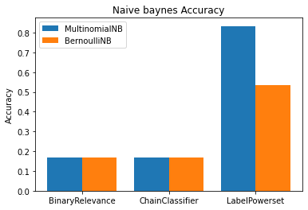

```python
multi_acc = (accuracy_score(y_test, multi_pred),accuracy_score(y_test, chain_multi_pred),accuracy_score(y_test, multi_power_pred))
bi_acc = (accuracy_score(y_test, bi_pred),accuracy_score(y_test, chain_bi_pred),accuracy_score(y_test, bi_power_pred))
width = 0.4
plt.bar(np.arange(3),multi_acc,width,label ="MultinomialNB")
plt.bar(np.arange(3)+width,bi_acc,width,label ="BernoulliNB")
plt.ylabel('Accuracy')
plt.title('Naive baynes Accuracy')

plt.xticks(np.arange(3) + width / 2, ('BinaryRelevance', 'ChainClassifier', 'LabelPowerset'))
plt.legend(loc='best')
plt.show()
```

กราฟแสดงการเปรียบเทียบความแม่นยำในการทำ train test split โดยมีโอกาสเป็น Lucky Split

```python
models_lst = [BinaryRelevance(),BinaryRelevance(),ClassifierChain(),ClassifierChain(),LabelPowerset(),LabelPowerset()]
parameter = [{
        'classifier': [MultinomialNB()],
        'classifier__alpha': [0.5,0.7, 1.0,10.0]
    },
    {
        'classifier':[BernoulliNB()],
        'classifier_alpha': [0.5,0.7,1.0,10.0]
    }
]

model_name = ['BinaryRelevanceMultinomial','BinaryRelevanceBernoulli','ClassifierChainMultinomial'\
             ,'ClassifierChainBernoulli','LabelPowersetMultinobial','LabelPowersetBernoulli']
```

```python
count = 0
for i in models_lst:
    # Choose cross-validation techniques for the inner and outer loops,
    # independently of the dataset.
    inner_cv = KFold(n_splits=4, shuffle=True, random_state=2)
    outer_cv = KFold(n_splits=4, shuffle=True, random_state=2)
    # Optimizing Parameter
    clf = GridSearchCV(i, parameter[0:1], cv=inner_cv)
    clf.fit(X, y)

    # Nested CV with parameter optimization
    nested_score = cross_val_score(clf, X, y, cv=outer_cv)
    print(model_name[count]+":  ")
    print('Nested_CV :  '+'%.2f ' %(nested_score.mean()*100)+' %')
    print('Best_parameter:  '+str(clf.best_params_))
    print('')
    count += 1
```

```
BinaryRelevanceMultinomial:
Nested_CV :  22.00  %
Best_parameter:  {'classifier': MultinomialNB(alpha=10.0), 'classifier__alpha': 10.0}

BinaryRelevanceBernoulli:
Nested_CV :  22.00  %
Best_parameter:  {'classifier': MultinomialNB(alpha=10.0), 'classifier__alpha': 10.0}

ClassifierChainMultinomial:
Nested_CV :  22.00  %
Best_parameter:  {'classifier': MultinomialNB(alpha=10.0), 'classifier__alpha': 10.0}

ClassifierChainBernoulli:
Nested_CV :  22.00  %
Best_parameter:  {'classifier': MultinomialNB(alpha=10.0), 'classifier__alpha': 10.0}

LabelPowersetMultinobial:
Nested_CV :  24.00  %
Best_parameter:  {'classifier': MultinomialNB(alpha=10.0), 'classifier__alpha': 10.0}

LabelPowersetBernoulli:
Nested_CV :  24.00  %
Best_parameter:  {'classifier': MultinomialNB(alpha=10.0), 'classifier__alpha': 10.0}
```

[figure not shown]

```python
fig, ax = plt.subplots(figsize = (18,10))
tts = (accuracy_score(y_test, multi_pred),accuracy_score(y_test, bi_pred),accuracy_score(y_test, chain_multi_pred),\
       accuracy_score(y_test, chain_bi_pred),accuracy_score(y_test, multi_power_pred),accuracy_score(y_test, bi_power_pred))
loo = (0.35,0.33,0.33,0.33,0.33,0.33)
nested = (0.22,0.22,0.22,0.22,0.24,0.24)
width = 0.2
plt.bar(np.arange(6),tts,width,label ="Train Test Split")
plt.bar(np.arange(6)+(width),loo,width,label ="Leave one out")
plt.bar(np.arange(6)+(2*width),nested,width,label ="Nested CV")
plt.ylabel('Accuracy')
plt.title('Naive baynes Accuracy')
plt.xlabel('Evaluation')
plt.xticks(np.arange(6) + (1.5*width) , ('BinaryRelevanceMultinomial','BinaryRelevanceBernoullib', \
                        'ChainClassifierMultinomial','ChainClassifierBernoullib', 'LabelPowersetMultinomial','LabelPowersetBernoullib'))
plt.legend(loc='best')
plt.grid()
plt.show()
```

### Naive Baynes Summary with Author Detail

ในการทดสอบ Naive Baynes เราได้ทำการทดสอบด้วย Naive Baynes สองแบบคือ Multinomial&Bernoulli

ถ้าหากเรา Tune parameter with gridsearch CV แล้วนำมาหา nested cv เราจะได้ความแม่นยำเป็น 22-24% ซึ่งน้อยลงจากการทำโดยไม่มีข้อมูลผู้แต่ง แต่หากเราสังเกตในส่วนของ train test split จะเห็นได้ว่าพอมีข้อมูลที่เยอะขึ้นการทำแบบ powewlable set สูงขึ้น อาจเป็นเพราะ lucky split เหมือนเคยแต่ความเหมาะสมในการดูข้อมูลทางความน่าจะเป็นของสูตรจะเห็นได้ว่ามันมีความต่างกันอยู่มากตามข้อมูล

## Tree

### RandomForest

```python
# random n_estimator โดยการใช้ numpy linspace
n_estimators = [int(x) for x in np.linspace(start = 5, stop = 60, num = 5)]
# Number of features ที่จะถูก split ออกมา
max_features = ['auto', 'sqrt']
# ความลึกสูงสุด (ไม่ควรลึกเกินไปและน้อยเกินไป)
max_depth = [2,4]
# Minimum samples ที่ใช้ในการแตก node
min_samples_split = [2, 5]
# Minimum samples required at each leaf node
min_samples_leaf = [1, 2]
# เลือกตัวอย่างในการ training ของต้นไม้แต่ละต้น
bootstrap = [True, False]
"""
    ใช้ข้อมูลจากด้านบนมาใส่ใน dick ในการจูนค่า parameter
"""
param_grid = {'n_estimators': n_estimators,
               'max_features': max_features,
               'max_depth': max_depth,
               'min_samples_split': min_samples_split,
               'min_samples_leaf': min_samples_leaf,
               'bootstrap': bootstrap}
```

```python
inner_cv = KFold(n_splits=4, shuffle=True, random_state=2)
outer_cv = KFold(n_splits=4, shuffle=True, random_state=2)
# Optimizing Parameter
clf = GridSearchCV(RandomForestClassifier(random_state=42), param_grid, verbose=2, cv=inner_cv,n_jobs=4) #Verbose =2 red box
#n_jobs คือให้ทำ task ขนาดกันเป็นจำนวน4
clf.fit(X, y)
# Nested CV with parameter optimization
nested_score = cross_val_score(clf, X, y, cv=outer_cv)
print('RandomForest : ')
print('Nested_CV :  '+'%.2f ' %(nested_score.mean()*100)+' %')
print('Best_parameter:  '+str(clf.best_params_))
print('')
```

```
Fitting 4 folds for each of 160 candidates, totalling 640 fits
```

```
[Parallel(n_jobs=4)]: Using backend LokyBackend with 4 concurrent workers.
[Parallel(n_jobs=4)]: Done  58 tasks      | elapsed:    1.2s
[Parallel(n_jobs=4)]: Done 300 tasks      | elapsed:    5.8s
[Parallel(n_jobs=4)]: Done 640 out of 640 | elapsed:   12.4s finished
[Parallel(n_jobs=4)]: Using backend LokyBackend with 4 concurrent workers.
```

```
Fitting 4 folds for each of 160 candidates, totalling 640 fits
```

```
[Parallel(n_jobs=4)]: Done  58 tasks      | elapsed:    1.2s
[Parallel(n_jobs=4)]: Done 300 tasks      | elapsed:    6.4s
[Parallel(n_jobs=4)]: Done 640 out of 640 | elapsed:   12.5s finished
[Parallel(n_jobs=4)]: Using backend LokyBackend with 4 concurrent workers.
```

```
Fitting 4 folds for each of 160 candidates, totalling 640 fits
```

```
[Parallel(n_jobs=4)]: Done  92 tasks      | elapsed:    2.0s
[Parallel(n_jobs=4)]: Done 576 tasks      | elapsed:   11.4s
[Parallel(n_jobs=4)]: Done 640 out of 640 | elapsed:   12.7s finished
[Parallel(n_jobs=4)]: Using backend LokyBackend with 4 concurrent workers.
```

```
Fitting 4 folds for each of 160 candidates, totalling 640 fits
```

```
[Parallel(n_jobs=4)]: Done  58 tasks      | elapsed:    1.2s
[Parallel(n_jobs=4)]: Done 300 tasks      | elapsed:    6.9s
[Parallel(n_jobs=4)]: Done 640 out of 640 | elapsed:   13.4s finished
[Parallel(n_jobs=4)]: Using backend LokyBackend with 4 concurrent workers.
```

```
Fitting 4 folds for each of 160 candidates, totalling 640 fits
```

```
[Parallel(n_jobs=4)]: Done  92 tasks      | elapsed:    1.6s
[Parallel(n_jobs=4)]: Done 576 tasks      | elapsed:    9.5s
```

```
RandomForest :
Nested_CV :  32.00  %
Best_parameter:  {'bootstrap': True, 'max_depth': 2, 'max_features': 'auto', 'min_samples_leaf': 1, 'min_samples_split': 2, 'n_estimators': 18}
```

```
[Parallel(n_jobs=4)]: Done 640 out of 640 | elapsed:   10.5s finished
```

verbosity level ref:http://www2.cs.uregina.ca/~dbd/cs831/notes/ml/dtrees/c4.5/verbrules.html

### Decision Tree

```python
params = {
        'max_leaf_nodes': list(range(2, 100)),
        'min_samples_split': [2, 3, 4]
            }
inner_cv = KFold(n_splits=4, shuffle=True, random_state=2)
outer_cv = KFold(n_splits=4, shuffle=True, random_state=2)
# Optimizing Parameter
clf = GridSearchCV(DecisionTreeClassifier(random_state=42), params, verbose=1, cv=inner_cv) #verbose=1คือกล่องสีแดงด้านล่าง
clf.fit(X, y)
# Nested CV with parameter optimization
nested_score = cross_val_score(clf, X, y, cv=outer_cv)
print('DecisionTree : ')
print('Nested_CV :  '+'%.2f ' %(nested_score.mean()*100)+' %')
print('Best_parameter:  '+str(clf.best_params_))
print('')
```

```
[Parallel(n_jobs=1)]: Using backend SequentialBackend with 1 concurrent workers.
```

```
Fitting 4 folds for each of 294 candidates, totalling 1176 fits
```

```
[Parallel(n_jobs=1)]: Done 1176 out of 1176 | elapsed:   21.9s finished
[Parallel(n_jobs=1)]: Using backend SequentialBackend with 1 concurrent workers.
```

```
Fitting 4 folds for each of 294 candidates, totalling 1176 fits
```

```
[Parallel(n_jobs=1)]: Done 1176 out of 1176 | elapsed:   17.8s finished
[Parallel(n_jobs=1)]: Using backend SequentialBackend with 1 concurrent workers.
```

```
Fitting 4 folds for each of 294 candidates, totalling 1176 fits
```

```
[Parallel(n_jobs=1)]: Done 1176 out of 1176 | elapsed:   18.2s finished
[Parallel(n_jobs=1)]: Using backend SequentialBackend with 1 concurrent workers.
```

```
Fitting 4 folds for each of 294 candidates, totalling 1176 fits
```

```
[Parallel(n_jobs=1)]: Done 1176 out of 1176 | elapsed:   19.0s finished
[Parallel(n_jobs=1)]: Using backend SequentialBackend with 1 concurrent workers.
```

```
Fitting 4 folds for each of 294 candidates, totalling 1176 fits
DecisionTree :
Nested_CV :  30.00  %
Best_parameter:  {'max_leaf_nodes': 7, 'min_samples_split': 2}
```

```
[Parallel(n_jobs=1)]: Done 1176 out of 1176 | elapsed:   18.3s finished
```

### Tree Summary

ในการใช้ Tree จะได้ค่าแม่นยำเพียง 36%และ37%ตามลำดับ โดยใช้ best parameter ตามที่ตั้งค่าเอาไว้ ลดลงมาเหลือเพียงแค่ 32%และ30%

## Logistic Regression

Test with BinaryRelevance and ClassifierChain

สำหรับ LabelPowerset การนำ LogisticRegression มาใช้ แบบ multi label จะดูไม่เหมาะสมต่อการทำ X ,y1,y2,...,yn

จึงเลือกใช้แค่สองวิธีแล้วนำมาเปรัยบเทียบกัน

```python
lr_pram = { 'classifier': [LogisticRegression()],
            'classifier__penalty':('l1', 'l2'),
              'classifier__solver':('newton-cg', 'lbfgs', 'liblinear', 'sag', 'saga'),
          'classifier__C':[0.01, 0.1, 1, 10]}
```

```python
inner_cv = KFold(n_splits=4, shuffle=True, random_state=2)
outer_cv = KFold(n_splits=4, shuffle=True, random_state=2)
# Optimizing Parameter
clf = GridSearchCV(BinaryRelevance(), lr_pram, cv=inner_cv)
clf.fit(X, y)
# Nested CV with parameter optimization
# nested_score = cross_val_score(clf, X, y, cv=outer_cv)
# print('LogisticRegression : ')
# print('Nested_CV :  '+'%.2f ' %(nested_score.mean()*100)+' %')
# print('Best_parameter:  '+str(clf.best_params_))
# print('')
"""ไม่สามารถรันที่เดียวได้เลยแยกรันโดยจูนพารามีเตอร์ตามด้านล่าง"""
```

```
'ไม่สามารถรันที่เดียวได้เลยแยกรันโดยจูนพารามีเตอร์ตามด้านล่าง'
```

```python
lr = LogisticRegression(solver='liblinear',penalty='l1')
```

```python
nested_score = cross_val_score(BinaryRelevance(lr), X, y, cv=outer_cv)
print('LogisticRegression : ')
print('Nested_CV :  '+'%.2f ' %(nested_score.mean()*100)+' %')
print('Best_parameter:  '+str(clf.best_params_))
print('')
```

```
LogisticRegression :
Nested_CV :  29.00  %
Best_parameter:  {'classifier': LogisticRegression(C=0.01, penalty='l1', solver='liblinear'), 'classifier__C': 0.01, 'classifier__penalty': 'l1', 'classifier__solver': 'liblinear'}
```

```python
clf = GridSearchCV(ClassifierChain(), lr_pram, cv=inner_cv)
clf.fit(X, y)
```

```
GridSearchCV(cv=KFold(n_splits=4, random_state=2, shuffle=True),
             estimator=ClassifierChain(require_dense=[True, True]),
             param_grid={'classifier': [LogisticRegression(C=0.01, penalty='l1',
                                                           solver='liblinear')],
                         'classifier__C': [0.01, 0.1, 1, 10],
                         'classifier__penalty': ('l1', 'l2'),
                         'classifier__solver': ('newton-cg', 'lbfgs',
                                                'liblinear', 'sag', 'saga')})
```

```python
nested_score = cross_val_score(ClassifierChain(lr), X, y, cv=outer_cv)
print('LogisticRegression : ')
print('Nested_CV :  '+'%.2f ' %(nested_score.mean()*100)+' %')
print('Best_parameter:  '+str(clf.best_params_))
print('')
```

```
LogisticRegression :
Nested_CV :  28.00  %
Best_parameter:  {'classifier': LogisticRegression(C=0.01, penalty='l1', solver='liblinear'), 'classifier__C': 0.01, 'classifier__penalty': 'l1', 'classifier__solver': 'liblinear'}
```

### Logistic Regression Summary with Author Detail

ในการใช้ Logistic Regression หา label เราได้ best parameter มาคือ C=1, penalty='l1', solver='liblinear' ให้ค่าความแม่นยำ 36% โดยเป็นการหาแบบ BinaryRelevance&ClassifierChain ด้วยการทำ NestCV แต่พอมีข้อมูลผู้แต่งมาจะทำให้คำศัพท์มันเยอะขึ้นแต่ไม่ช่วยในการทำนายความแม่นยำมิหนำซ้ำยังส่งผลให้ทำงานหาความแม่นยำได้แย่ลงอีกด้วย

## Multilabel kNN

```python
X_knn = lil_matrix(X).toarray()
y_knn = lil_matrix(y).toarray()
knn_pram = {'k': range(1,15), 's': [0.5, 0.7, 1.0]}
inner_cv = KFold(n_splits=4, shuffle=True, random_state=2)
outer_cv = KFold(n_splits=4, shuffle=True, random_state=2)
# Optimizing Parameter
clf = GridSearchCV(MLkNN(), knn_pram, cv=inner_cv)
clf.fit(X_knn, y_knn)
# Nested CV with parameter optimization
nested_score = cross_val_score(clf, X_knn, y_knn, cv=outer_cv)
print('Multiple kNN : ')
print('Nested_CV :  '+'%.2f ' %(nested_score.mean()*100)+' %')
print('Best_parameter:  '+str(clf.best_params_))
print('')
```

```
Multiple kNN :
Nested_CV :  33.00  %
Best_parameter:  {'k': 6, 's': 0.5}
```

### MLkNN Summary

จากการทำ GridSearchCV ได้ parameter ที่ดีคือใช้ k=7 และ s =0.7 โดยให้ความแม่นยำอยู่ที่ 35% พอมีข้อมูลผู้แต่งมาต่อทำให้การแบ่งกลุ่มนั้นน้อยลงโดยใช้ k=6 s=0.5 แต่ให้ความแม่นยำเพียงแค่ 33%

## Less Word

min_df = 5

```python
vectorizer = CountVectorizer(stop_words="english",min_df = 5, tokenizer= lemma_tokenizer)
X = vectorizer.fit_transform(mix_data)
X.shape
```

```
(100, 737)
```

### Naive Baynes with BinaryRelevance

```python
bnr_rlv_multi = BinaryRelevance(MultinomialNB())
bnr_rlv_bi = BinaryRelevance(BernoulliNB(alpha=0.7))
bnr_rlv_multi.fit(X_train,y_train)
multi_pred = bnr_rlv_multi.predict(X_test)
bnr_rlv_bi.fit(X_train,y_train)
bi_pred = bnr_rlv_bi.predict(X_test)
"""
    กำหนด labels ในตัว precision&recall เป็น 0ม1 ตาม binary ของคำตอบที่เราแบ่งmulti label ให้มี 0,1
"""
print("|-------------------- Accuracy Testing --------------------|")
print(" Multinomia Naive Baynes accuracy: ",accuracy_score(y_test, multi_pred))
print(" Precision Score Multinomial: ",precision_score(y_test,multi_pred,labels=[0,1],average='micro'))
print(" Recall Score Multinomial: ",recall_score(y_test, multi_pred,labels=[0,1],average='micro'))
print("|----------------------------------------------------------|")
print(" Bernoulib Naive Baynes accuracy: ",accuracy_score(y_test, bi_pred))
print(" Precision Score Bernoulib: ",precision_score(y_test,bi_pred,labels=[0,1],average='micro'))
print(" Recall Score Bernoulib: ",recall_score(y_test,bi_pred,labels=[0,1],average='micro'))
```

```
|-------------------- Accuracy Testing --------------------|
 Multinomia Naive Baynes accuracy:  0.16666666666666666
 Precision Score Multinomial:  0.1
 Recall Score Multinomial:  0.2
|----------------------------------------------------------|
 Bernoulib Naive Baynes accuracy:  0.16666666666666666
 Precision Score Bernoulib:  0.0
 Recall Score Bernoulib:  0.0
```

เราจะเห็นว่า Multinomial สามารถทายผล class และ ความถูกต้องโดยรวมของข้อมูลได้ แม่นยำกว่า แม้ accuracy ของโมเดลจะเท่ากันก็ตาม

### Testing with Leave one out

```python
scores1 = cross_val_score(BinaryRelevance(MultinomialNB()) , X , y , cv = X.shape[0])
scores2 = cross_val_score(BinaryRelevance(BernoulliNB(alpha=0.7)) , X , y , cv = X.shape[0])
```

```python
print("Multinomial Accuracy: %0.2f (+/- %0.2f)" % (scores1.mean()*100, scores1.std()))
print("Bernoulib Accuracy: %0.2f (+/- %0.2f)" % (scores2.mean()*100, scores2.std()))
```

```
Multinomial Accuracy: 13.00 (+/- 0.34)
Bernoulib Accuracy: 19.00 (+/- 0.39)
```

### Naive Bayne with ClassifierChain

```python
chain_multi = ClassifierChain(MultinomialNB())
chain_bi = ClassifierChain(BernoulliNB(alpha=0.7))
chain_multi.fit(X_train,y_train)
chain_multi_pred = chain_multi.predict(X_test)
chain_bi.fit(X_train,y_train)
chain_bi_pred = chain_bi.predict(X_test)
print("|-------------------- Accuracy Testing --------------------|")
print(" Multinomia Naive Baynes accuracy: ",accuracy_score(y_test, chain_multi_pred))
print(" Precision Score Multinomail: ",precision_score(y_test, chain_multi_pred,labels=[0,1],average='micro'))
print(" Recall Score Multinomial: ",recall_score(y_test, chain_multi_pred,labels=[0,1],average='micro'))
print("|----------------------------------------------------------|")
print(" Bernoulib Naive Baynes accuracy: ",accuracy_score(y_test, chain_bi_pred))
print(" Precision Score Bernoulib: ",precision_score(y_test, chain_bi_pred,labels=[0,1],average='micro'))
print(" Recall Score Bernoulib: ",recall_score(y_test,chain_bi_pred,labels=[0,1],average='micro'))
```

```
|-------------------- Accuracy Testing --------------------|
 Multinomia Naive Baynes accuracy:  0.16666666666666666
 Precision Score Multinomail:  0.1
 Recall Score Multinomial:  0.2
|----------------------------------------------------------|
 Bernoulib Naive Baynes accuracy:  0.16666666666666666
 Precision Score Bernoulib:  0.0
 Recall Score Bernoulib:  0.0
```

จาก ClassifierChain เราะเห็นได้ว่าแม้ความแม่นยำจะต่างไปไม่มาก แต่ค่า Recall&Precision จะต่างกันอยู่ถึง 20%

### Testing with Leave one out

```python
scores1 = cross_val_score(ClassifierChain(MultinomialNB()) , X , y , cv = X.shape[0])
scores2 = cross_val_score(ClassifierChain(BernoulliNB(alpha=0.7)) , X , y , cv = X.shape[0])
print("Multinomial Accuracy: %0.2f (+/- %0.2f)" % (scores1.mean()*100, scores1.std()))
print("Bernoulib Accuracy: %0.2f (+/- %0.2f)" % (scores2.mean()*100, scores2.std()))
```

```
Multinomial Accuracy: 13.00 (+/- 0.34)
Bernoulib Accuracy: 19.00 (+/- 0.39)
```

### Naive Baynes with LabelPowerset

```python
multi_power = LabelPowerset(MultinomialNB())
bi_power = LabelPowerset(BernoulliNB(alpha=0.7))
multi_power.fit(X_test,y_test)
multi_power_pred = multi_power.predict(X_test)
bi_power.fit(X_test,y_test)
bi_power_pred = bi_power.predict(X_test)
print("|-------------------- Accuracy Testing --------------------|")
print(" Multinomia Naive Baynes accuracy: ",accuracy_score(y_test, multi_power_pred))
print(" Precision Score : ",precision_score(y_test, multi_power_pred,labels=[0,1],average='micro'))
print(" Recall Score : ",recall_score(y_test, multi_power_pred,labels=[0,1],average='micro'))
print("|----------------------------------------------------------|")
print(" Bernoulib Naive Baynes accuracy: ",accuracy_score(y_test, bi_power_pred))
print(" Precision Score : ",precision_score(y_test, bi_power_pred,average='micro'))
print(" Recall Score : ",recall_score(y_test, bi_power_pred,average='micro'))
```

```
|-------------------- Accuracy Testing --------------------|
 Multinomia Naive Baynes accuracy:  0.8333333333333334
 Precision Score :  1.0
 Recall Score :  0.8
|----------------------------------------------------------|
 Bernoulib Naive Baynes accuracy:  0.5333333333333333
 Precision Score :  0.7
 Recall Score :  0.45161290322580644
```

### Testing with Leave one out

```python
scores1 = cross_val_score(multi_power , X , y , cv = X.shape[0])
scores2 = cross_val_score( bi_power, X , y , cv = X.shape[0])
print("Multinomial Accuracy: %0.2f (+/- %0.2f)" % (scores1.mean()*100, scores1.std()))
print("Bernoulib Accuracy: %0.2f (+/- %0.2f)" % (scores2.mean()*100, scores2.std()))
```

```
Multinomial Accuracy: 24.00 (+/- 0.43)
Bernoulib Accuracy: 11.00 (+/- 0.31)
```

Label Powerset traines on all unique label combinations found in the training data. ดังนั้น การทำการคำนวณหรือ test ที่มีการซับซ้อนหรือเยอะเช่นการเปรียบเทียบที่เยอะเกินไปอาจทำให้ความแม่นยำลดลง

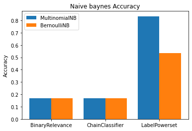

```python
multi_acc = (accuracy_score(y_test, multi_pred),accuracy_score(y_test, chain_multi_pred),accuracy_score(y_test, multi_power_pred))
bi_acc = (accuracy_score(y_test, bi_pred),accuracy_score(y_test, chain_bi_pred),accuracy_score(y_test, bi_power_pred))
width = 0.4
plt.bar(np.arange(3),multi_acc,width,label ="MultinomialNB")
plt.bar(np.arange(3)+width,bi_acc,width,label ="BernoulliNB")
plt.ylabel('Accuracy')
plt.title('Naive baynes Accuracy')

plt.xticks(np.arange(3) + width / 2, ('BinaryRelevance', 'ChainClassifier', 'LabelPowerset'))
plt.legend(loc='best')
plt.show()
```

กราฟแสดงการเปรียบเทียบความแม่นยำในการทำ train test split โดยมีโอกาสเป็น Lucky Split

```python
models_lst = [BinaryRelevance(),BinaryRelevance(),ClassifierChain(),ClassifierChain(),LabelPowerset(),LabelPowerset()]
parameter = [{
        'classifier': [MultinomialNB()],
        'classifier__alpha': [0.5,0.7, 1.0,10.0]
    },
    {
        'classifier':[BernoulliNB()],
        'classifier_alpha': [0.5,0.7,1.0,10.0]
    }
]

model_name = ['BinaryRelevanceMultinomial','BinaryRelevanceBernoulli','ClassifierChainMultinomial'\
             ,'ClassifierChainBernoulli','LabelPowersetMultinobial','LabelPowersetBernoulli']
```

```python
count = 0
for i in models_lst:
    # Choose cross-validation techniques for the inner and outer loops,
    # independently of the dataset.
    inner_cv = KFold(n_splits=4, shuffle=True, random_state=2)
    outer_cv = KFold(n_splits=4, shuffle=True, random_state=2)
    # Optimizing Parameter
    clf = GridSearchCV(i, parameter[0:1], cv=inner_cv)
    clf.fit(X, y)

    # Nested CV with parameter optimization
    nested_score = cross_val_score(clf, X, y, cv=outer_cv)
    print(model_name[count]+":  ")
    print('Nested_CV :  '+'%.2f ' %(nested_score.mean()*100)+' %')
    print('Best_parameter:  '+str(clf.best_params_))
    print('')
    count += 1
```

```
BinaryRelevanceMultinomial:
Nested_CV :  24.00  %
Best_parameter:  {'classifier': MultinomialNB(alpha=10.0), 'classifier__alpha': 10.0}

BinaryRelevanceBernoulli:
Nested_CV :  24.00  %
Best_parameter:  {'classifier': MultinomialNB(alpha=10.0), 'classifier__alpha': 10.0}

ClassifierChainMultinomial:
Nested_CV :  24.00  %
Best_parameter:  {'classifier': MultinomialNB(alpha=10.0), 'classifier__alpha': 10.0}

ClassifierChainBernoulli:
Nested_CV :  24.00  %
Best_parameter:  {'classifier': MultinomialNB(alpha=10.0), 'classifier__alpha': 10.0}

LabelPowersetMultinobial:
Nested_CV :  27.00  %
Best_parameter:  {'classifier': MultinomialNB(alpha=10.0), 'classifier__alpha': 10.0}

LabelPowersetBernoulli:
Nested_CV :  27.00  %
Best_parameter:  {'classifier': MultinomialNB(alpha=10.0), 'classifier__alpha': 10.0}
```

[figure not shown]

```python
fig, ax = plt.subplots(figsize = (18,10))
tts = (accuracy_score(y_test, multi_pred),accuracy_score(y_test, bi_pred),accuracy_score(y_test, chain_multi_pred),\
       accuracy_score(y_test, chain_bi_pred),accuracy_score(y_test, multi_power_pred),accuracy_score(y_test, bi_power_pred))
loo = (0.35,0.33,0.33,0.33,0.33,0.33)
nested = (0.24,0.24,0.24,0.24,0.27,0.27)
width = 0.2
plt.bar(np.arange(6),tts,width,label ="Train Test Split")
plt.bar(np.arange(6)+(width),loo,width,label ="Leave one out")
plt.bar(np.arange(6)+(2*width),nested,width,label ="Nested CV")
plt.ylabel('Accuracy')
plt.title('Naive baynes Accuracy')
plt.xlabel('Evaluation')
plt.xticks(np.arange(6) + (1.5*width) , ('BinaryRelevanceMultinomial','BinaryRelevanceBernoullib', \
                        'ChainClassifierMultinomial','ChainClassifierBernoullib', 'LabelPowersetMultinomial','LabelPowersetBernoullib'))
plt.legend(loc='best')
plt.grid()
plt.show()
```

### Naive Baynes Summary with Author Detail & Less Word Weight

ในการทดสอบ Naive Baynes เราได้ทำการทดสอบด้วย Naive Baynes สองแบบคือ Multinomial&Bernoulli

## Tree

### RandomForest

```python
# random n_estimator โดยการใช้ numpy linspace
n_estimators = [int(x) for x in np.linspace(start = 5, stop = 60, num = 5)]
# Number of features ที่จะถูก split ออกมา
max_features = ['auto', 'sqrt']
# ความลึกสูงสุด (ไม่ควรลึกเกินไปและน้อยเกินไป)
max_depth = [2,4]
# Minimum samples ที่ใช้ในการแตก node
min_samples_split = [2, 5]
# Minimum samples required at each leaf node
min_samples_leaf = [1, 2]
# เลือกตัวอย่างในการ training ของต้นไม้แต่ละต้น
bootstrap = [True, False]
"""
    ใช้ข้อมูลจากด้านบนมาใส่ใน dick ในการจูนค่า parameter
"""
param_grid = {'n_estimators': n_estimators,
               'max_features': max_features,
               'max_depth': max_depth,
               'min_samples_split': min_samples_split,
               'min_samples_leaf': min_samples_leaf,
               'bootstrap': bootstrap}
```

```python
inner_cv = KFold(n_splits=4, shuffle=True, random_state=2)
outer_cv = KFold(n_splits=4, shuffle=True, random_state=2)
# Optimizing Parameter
clf = GridSearchCV(RandomForestClassifier(random_state=42), param_grid, verbose=2, cv=inner_cv,n_jobs=4) #Verbose =2 red box
#n_jobs คือใส้ทำ task ขนาดกันเป็นจำนวน4
clf.fit(X, y)
# Nested CV with parameter optimization
nested_score = cross_val_score(clf, X, y, cv=outer_cv)
print('RandomForest : ')
print('Nested_CV :  '+'%.2f ' %(nested_score.mean()*100)+' %')
print('Best_parameter:  '+str(clf.best_params_))
print('')
```

```
Fitting 4 folds for each of 160 candidates, totalling 640 fits
```

```
[Parallel(n_jobs=4)]: Using backend LokyBackend with 4 concurrent workers.
[Parallel(n_jobs=4)]: Done  92 tasks      | elapsed:    1.5s
[Parallel(n_jobs=4)]: Done 576 tasks      | elapsed:    9.4s
[Parallel(n_jobs=4)]: Done 640 out of 640 | elapsed:   10.5s finished
[Parallel(n_jobs=4)]: Using backend LokyBackend with 4 concurrent workers.
```

```
Fitting 4 folds for each of 160 candidates, totalling 640 fits
```

```
[Parallel(n_jobs=4)]: Done  92 tasks      | elapsed:    1.5s
[Parallel(n_jobs=4)]: Done 576 tasks      | elapsed:    9.6s
[Parallel(n_jobs=4)]: Done 640 out of 640 | elapsed:   10.8s finished
[Parallel(n_jobs=4)]: Using backend LokyBackend with 4 concurrent workers.
```

```
Fitting 4 folds for each of 160 candidates, totalling 640 fits
```

```
[Parallel(n_jobs=4)]: Done  58 tasks      | elapsed:    1.1s
[Parallel(n_jobs=4)]: Done 300 tasks      | elapsed:    5.8s
[Parallel(n_jobs=4)]: Done 640 out of 640 | elapsed:   11.2s finished
[Parallel(n_jobs=4)]: Using backend LokyBackend with 4 concurrent workers.
```

```
Fitting 4 folds for each of 160 candidates, totalling 640 fits
```

```
[Parallel(n_jobs=4)]: Done  92 tasks      | elapsed:    1.5s
[Parallel(n_jobs=4)]: Done 576 tasks      | elapsed:    9.2s
[Parallel(n_jobs=4)]: Done 640 out of 640 | elapsed:   10.2s finished
[Parallel(n_jobs=4)]: Using backend LokyBackend with 4 concurrent workers.
```

```
Fitting 4 folds for each of 160 candidates, totalling 640 fits
```

```
[Parallel(n_jobs=4)]: Done  92 tasks      | elapsed:    1.6s
[Parallel(n_jobs=4)]: Done 576 tasks      | elapsed:   10.7s
```

```
RandomForest :
Nested_CV :  33.00  %
Best_parameter:  {'bootstrap': True, 'max_depth': 2, 'max_features': 'auto', 'min_samples_leaf': 1, 'min_samples_split': 2, 'n_estimators': 5}
```

```
[Parallel(n_jobs=4)]: Done 640 out of 640 | elapsed:   11.9s finished
```

verbosity level ref:http://www2.cs.uregina.ca/~dbd/cs831/notes/ml/dtrees/c4.5/verbrules.html

### Decision Tree

```python
params = {
        'max_leaf_nodes': list(range(2, 100)),
        'min_samples_split': [2, 3, 4]
            }
inner_cv = KFold(n_splits=4, shuffle=True, random_state=2)
outer_cv = KFold(n_splits=4, shuffle=True, random_state=2)
# Optimizing Parameter
clf = GridSearchCV(DecisionTreeClassifier(random_state=42), params, verbose=1, cv=inner_cv) #verbose=1คือกล่องสีแดงด้านล่าง
clf.fit(X, y)
# Nested CV with parameter optimization
nested_score = cross_val_score(clf, X, y, cv=outer_cv)
print('DecisionTree : ')
print('Nested_CV :  '+'%.2f ' %(nested_score.mean()*100)+' %')
print('Best_parameter:  '+str(clf.best_params_))
print('')
```

```
[Parallel(n_jobs=1)]: Using backend SequentialBackend with 1 concurrent workers.
```

```
Fitting 4 folds for each of 294 candidates, totalling 1176 fits
```

```
[Parallel(n_jobs=1)]: Done 1176 out of 1176 | elapsed:   18.4s finished
[Parallel(n_jobs=1)]: Using backend SequentialBackend with 1 concurrent workers.
```

```
Fitting 4 folds for each of 294 candidates, totalling 1176 fits
```

```
[Parallel(n_jobs=1)]: Done 1176 out of 1176 | elapsed:   16.2s finished
[Parallel(n_jobs=1)]: Using backend SequentialBackend with 1 concurrent workers.
```

```
Fitting 4 folds for each of 294 candidates, totalling 1176 fits
```

```
[Parallel(n_jobs=1)]: Done 1176 out of 1176 | elapsed:   14.7s finished
[Parallel(n_jobs=1)]: Using backend SequentialBackend with 1 concurrent workers.
```

```
Fitting 4 folds for each of 294 candidates, totalling 1176 fits
```

```
[Parallel(n_jobs=1)]: Done 1176 out of 1176 | elapsed:   15.5s finished
[Parallel(n_jobs=1)]: Using backend SequentialBackend with 1 concurrent workers.
```

```
Fitting 4 folds for each of 294 candidates, totalling 1176 fits
DecisionTree :
Nested_CV :  27.00  %
Best_parameter:  {'max_leaf_nodes': 2, 'min_samples_split': 2}
```

```
[Parallel(n_jobs=1)]: Done 1176 out of 1176 | elapsed:   14.4s finished
```

### Tree Summary

ในการใช้ Tree จะได้ค่าแม่นยำเพียง 36%และ37%ตามลำดับ โดยใช้ best parameter ตามที่ตั้งค่าเอาไว้ ลดลงมาเหลือเพียงแค่ 32%และ30% ก่อนที่จะเปลี่ยนมาเป็น 33%และ27%

## Logistic Regression

Test with BinaryRelevance and ClassifierChain

สำหรับ LabelPowerset การนำ LogisticRegression มาใช้ แบบ multi label จะดูไม่เหมาะสมต่อการทำ X ,y1,y2,...,yn

จึงเลือกใช้แค่สองวิธีแล้วนำมาเปรัยบเทียบกัน

```python
lr_pram = { 'classifier': [LogisticRegression()],
            'classifier__penalty':('l1', 'l2'),
              'classifier__solver':('newton-cg', 'lbfgs', 'liblinear', 'sag', 'saga'),
          'classifier__C':[0.01, 0.1, 1, 10]}
```

```python
inner_cv = KFold(n_splits=4, shuffle=True, random_state=2)
outer_cv = KFold(n_splits=4, shuffle=True, random_state=2)
# Optimizing Parameter
clf = GridSearchCV(BinaryRelevance(), lr_pram, cv=inner_cv)
clf.fit(X, y)
# Nested CV with parameter optimization
# nested_score = cross_val_score(clf, X, y, cv=outer_cv)
# print('LogisticRegression : ')
# print('Nested_CV :  '+'%.2f ' %(nested_score.mean()*100)+' %')
# print('Best_parameter:  '+str(clf.best_params_))
# print('')
"""ไม่สามารถรันที่เดียวได้เลยแยกรันโดยจูนพารามีเตอร์ตามด้านล่าง"""
```

```
'ไม่สามารถรันที่เดียวได้เลยแยกรันโดยจูนพารามีเตอร์ตามด้านล่าง'
```

```python
lr = LogisticRegression(solver='liblinear',penalty='l1')
```

```python
nested_score = cross_val_score(BinaryRelevance(lr), X, y, cv=outer_cv)
print('LogisticRegression : ')
print('Nested_CV :  '+'%.2f ' %(nested_score.mean()*100)+' %')
print('Best_parameter:  '+str(clf.best_params_))
print('')
```

```
LogisticRegression :
Nested_CV :  29.00  %
Best_parameter:  {'classifier': LogisticRegression(C=0.01, penalty='l1', solver='liblinear'), 'classifier__C': 0.01, 'classifier__penalty': 'l1', 'classifier__solver': 'liblinear'}
```

```python
clf = GridSearchCV(ClassifierChain(), lr_pram, cv=inner_cv)
clf.fit(X, y)
```

```
GridSearchCV(cv=KFold(n_splits=4, random_state=2, shuffle=True),
             estimator=ClassifierChain(require_dense=[True, True]),
             param_grid={'classifier': [LogisticRegression(C=0.01, penalty='l1',
                                                           solver='liblinear')],
                         'classifier__C': [0.01, 0.1, 1, 10],
                         'classifier__penalty': ('l1', 'l2'),
                         'classifier__solver': ('newton-cg', 'lbfgs',
                                                'liblinear', 'sag', 'saga')})
```

```python
nested_score = cross_val_score(ClassifierChain(lr), X, y, cv=outer_cv)
print('LogisticRegression : ')
print('Nested_CV :  '+'%.2f ' %(nested_score.mean()*100)+' %')
print('Best_parameter:  '+str(clf.best_params_))
print('')
```

```
LogisticRegression :
Nested_CV :  29.00  %
Best_parameter:  {'classifier': LogisticRegression(C=0.01, penalty='l1', solver='liblinear'), 'classifier__C': 0.01, 'classifier__penalty': 'l1', 'classifier__solver': 'liblinear'}
```

### Logistic Regression Summary with Author Detail

ในการใช้ Logistic Regression หา label เราได้ best parameter มาคือ C=1, penalty='l1', solver='liblinear' ให้ค่าความแม่นยำ 36% โดยเป็นการหาแบบ BinaryRelevance&ClassifierChain ด้วยการทำ NestCV แต่พอมีข้อมูลผู้แต่งมาจะทำให้คำศัพท์มันเยอะขึ้นแต่ไม่ช่วยในการทำนายความแม่นยำมิหนำซ้ำยังส่งผลให้ทำงานหาความแม่นยำได้แย่ลงอีกด้วย

## Multilabel kNN

```python
X_knn = lil_matrix(X).toarray()
y_knn = lil_matrix(y).toarray()
knn_pram = {'k': range(1,15), 's': [0.5, 0.7, 1.0]}
inner_cv = KFold(n_splits=4, shuffle=True, random_state=2)
outer_cv = KFold(n_splits=4, shuffle=True, random_state=2)
# Optimizing Parameter
clf = GridSearchCV(MLkNN(), knn_pram, cv=inner_cv)
clf.fit(X_knn, y_knn)
# Nested CV with parameter optimization
nested_score = cross_val_score(clf, X_knn, y_knn, cv=outer_cv)
print('Multiple kNN : ')
print('Nested_CV :  '+'%.2f ' %(nested_score.mean()*100)+' %')
print('Best_parameter:  '+str(clf.best_params_))
print('')
```

```
Multiple kNN :
Nested_CV :  34.00  %
Best_parameter:  {'k': 7, 's': 1.0}
```

### MLkNN Summary

จากการทำ GridSearchCV ได้ parameter ที่ดีคือใช้ k=7 และ s =0.7 โดยให้ความแม่นยำอยู่ที่ 35% พอมีข้อมูลผู้แต่งมาต่อทำให้การแบ่งกลุ่มนั้นน้อยลงโดยใช้ k=6 s=0.5 แต่ให้ความแม่นยำเพียงแค่ 33% ถ้าเราใช้ Weight Less word มา จะแบ่งกลุ่ม k=7 s=1.0 โดยมีความแม่นยำเปลี่ยนเป็น 34%

# สรุป

ในการทำ text mining quote ได้ทำหลักๆคือสามแบบคือ

```
1.ทำ lemma กับข้อมูล quote ธรรมดา
2.ทำ lemma กับข้อมูล quote และ ข้อมูล Author details โดยกำหนด weight มีคำเยอะ ตั้งค่า min_df = 3
3.ทำ lemma กับข้อมูล quote และ ข้อมูล Author details โดยกำหนด weight มีคำน้อย ตั้งค่า min_df = 5
```

ซึ่งหลักการในการทำคือการนำข้อมูลเข้าโมเดลโดยใช้ lemma tokenize โดยหลักจากเก็บ Token เข้าโมเดลต่าง ๆ จะได้ค่าที่แตกต่างกัน

ในการทำนั้นได้ใช้โมเดลที่แตกต่างกันออกไปโดยเลือกใช้ Naive Baynes แบบ Multinomial & Bernoulli โดยใช้ Classifier multi learn

คือ BinaryRelevance, Classifierchain , PowerLabelset โดยเราจะลองทำ Train test split ก่อนในเบื้องต้นเพื่อดูว่าความแม่นยำเป็นอย่างไร

ก่อนที่จะ test ด้วย Leave one out หลังจากนั้นจะทำการ tune parameter แล้วเข้า nestedcv เพื่อหาค่าความแม่นยำออกมา

มีการทำ Logistic Regression with BinaryRelevance และ Classifier chain, Decision Tree, RandomForest, MlkNN

โดยขั้นตอนการทำจะซ้้ำกันทั้งสามแบบจะดูค่าความแม่นยำที่ออกมา ซึ่งบางข้อมูล การจัดการ parameter อาจจะต่างกันเนื่องจากการทำ

GridSearchCV จะให้ parameter ที่เหมาะสมต่อข้อมูลนั้น ๆ

ความแม่นยำในการทำโมเดลแต่ะข้อมูลจะเกาะกลุ่มกันไปในแต่ละโมเดลตามที่สังเกตได้

โดยความแม่นยำที่ดีที่สุด หลังจากการทำในแต่ละโมเดลคือ Decision tree 37% ในแบบแรก 33% ใน MlkNN ในแบบที่สอง และ 34% ใน MlkNN ในข้อมูลแบบที่3

ซึ่งหากนับ train test split มันจะมีค่าความแม่นยำสูงถึง 80% ในข้อมูลแบบที่สาม แต่ก็ไม่สามารถบอกได้แน่นอนว่ามันเป็น lucky split หรือ ไม่

หรือถ้านับ leave one out ก็อาจจะได้ค่าที่ดี แต่ parameter อาจจะยังไม่ถูกต้องตามที่ควร

ข้อมูลแบบที่สองและสาม จะมีความต่างกันโดยข้อมูลที่ได้อาจจะมีการตัดคำทำให้ในแต่ละโมเดลจะหาค่าความแม่นยำได้ต่างกันแต่โดยรวมการกำหนด min_df ที่น้อยกว่า ให้ค่าความแม่นยำที่น้อยกว่าในโมเดลต่าง ๆ

# Appendix

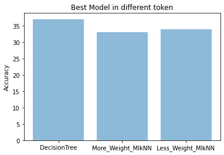

```python
objects = ('DecisionTree', 'More_Weight_MlkNN', 'Less_Weight_MlkNN')#DT มาจาก ข้อมูล quote, MW_mlknn มาจากquote+author min_df=3
y_pos = np.arange(len(objects))                                     #LW มาจาก quote+author min_df = 5
performance = [37,33,34,]

plt.bar(y_pos, performance, align='center', alpha=0.5)
plt.xticks(y_pos, objects)
plt.ylabel('Accuracy')
plt.title('Best Model in different token')

plt.show()
```

กราฟแสดงค่าความแม่นยำของโมเดลที่ดีที่สุดในข้อมูลแต่ละแบบ

[figure not shown]

```python
fig, ax = plt.subplots(figsize = (10,10))
objects = ('MW_DecisionTree','LW_DecisionTree', 'MW_RandomForest', 'LW_RandomForest')#MW = More_Weight, LW = Low
y_pos = np.arange(len(objects))
performance = [32,33,30,27,]

plt.bar(y_pos, performance, align='center', alpha=0.5)
plt.xticks(y_pos, objects)
plt.ylabel('Accuracy')
plt.title('Best Model in different token')

plt.grid()
plt.show()
```

กราฟเปรียบเทียบ tree ในแต่ละข้อมูล